Mónica Fernandes(PG42878), Tiago Machado (PG42884), Tiago Silva (PG42885)

16/05/21

# 1 *Packages*

Instalação dos *packages*.

```r
install.packages("tidyverse")

install.packages("arules")

install.packages("data.table")

install.packages("summarytools")

install.packages("ggpubr")

if (!requireNamespace("BiocManager", quietly = TRUE))
    install.packages("BiocManager")

BiocManager::install("limma")

if (!requireNamespace("BiocManager", quietly = TRUE))
    install.packages("BiocManager")

BiocManager::install("Glimma")

if (!requireNamespace("BiocManager", quietly = TRUE))
    install.packages("BiocManager")

BiocManager::install("edgeR")

if (!requireNamespace("BiocManager", quietly = TRUE))
    install.packages("BiocManager")

BiocManager::install("org.Hs.eg.db")

if (!requireNamespace("BiocManager", quietly = TRUE))
    install.packages("BiocManager")

BiocManager::install("GO.db")

install.packages("car")
```

Importação dos *packages*.

```r
library(readr)
library(readxl)
library(data.table)
library(tidyverse)
library(arules)
library(dplyr)
library(summarytools)
library(ggpubr)
library(limma)
library(Glimma)
library(edgeR)
library(org.Hs.eg.db)
library(GO.db)
library(car)
```

# 2 *Datasets*

```r
#dataset contagens
raw_counts <- read_csv("CCLE_RNAseq_reads.csv")

#dataset mutações
CCLE_mutations <- read_csv("CCLE_mutations.csv")

#dataset drug residtance
drug_response <- read.csv("primary-screen-replicate-collapsed-logfold-change.csv")

#dataset com as informações
sample_info <- read_excel("sample_info.xlsx")
```

## 2.1 Explicação dos dados, sua origem e relevância.

No âmbito do trabalho da UC Extração de Conhecimento de Bases de Dados Biológicas, foram extraídos 4 datasets da base de dados [DepMap](https://depmap.org/portal/). A base de dados contém inúmeros *datasets*, e o seu objetivo é disponibilizar vários tipos de dados relativos a linhagens celulares cancerígenas de uma forma *opensource*. Para tal recorre ao projeto *Achilles*, que tem como objetivo identificar e catalogar a essencialidade genética, transversal a centenas de linhagens de células cancerígenas. Recorre também ao projeto *CCLE* (*Cancer Cell Line Encyclopedia*), que tem como objetivo realizar a caracterização genética e farmacológica de uma vasta quantidade de modelos de cancro humano.  
Foi-nos proposto utilizar um *dataset* de expressão genética obtido por RNAseq para genes codificantes de proteínas (**raw_counts**), sendo este o nosso *dataset* **primário**. Mais especificamente, o *dataset* utilizado corresponde a contagens cruas provenientes do projeto *Achilles*, e dados de caracterização genética do projeto *CCLE*.  
Utilizamos também um *dataset* baseado num *Mutation Annotation Format* (*MAF*), isto é, um conjunto de informações de mutações provenientes de ficheiros “*VCF*” sendo gerados ao nível de projetos. Estas anotações provém dos mesmos projetos do *dataset* de expressão. Este *dataset* (**CCLE_mutations**) corresponde ao nosso *dataset* **secundário**.  
Como metadado utilizamos o *dataset* **drug_response** que resulta de uma tentativa de acessar o potencial anti-cancerígeno de um conjunto de fármacos não oncológicos, sobre linhagens cancerígenas humanas. Este *dataset* corresponde à viabilidade de linhagens cancerígenas humanas quando expostas aos compostos referidos.  
Por último, utilizamos o *dataset* **sample_info** que corresponde a informações variadas sobre as linhagens a que se referem os restantes *datasets*.

## 2.2 Preparação das variáveis

### 2.2.1 Dimensão e estrutura

#### raw_counts

```r
dim(raw_counts)
```

```
## [1]  1379 52440
```

```r
str(raw_counts, give.attr=FALSE)
```

```
## spec_tbl_df [1,379 x 52,440] (S3: spec_tbl_df/tbl_df/tbl/data.frame)
##  $ X1                                         : chr [1:1379] "ACH-001113" "ACH-001289" "ACH-001339" "ACH-001538" ...
##  $ TSPAN6 (ENSG00000000003)                   : num [1:1379] 2383 2529 1552 5657 22806 ...
##  $ TNMD (ENSG00000000005)                     : num [1:1379] 0 13 0 0 0 5 0 0 0 0 ...
##  $ DPM1 (ENSG00000000419)                     : num [1:1379] 4766 3857 8057 6056 4702 ...
##  $ SCYL3 (ENSG00000000457)                    : num [1:1379] 962 555 849 1057 1109 ...
##  $ C1orf112 (ENSG00000000460)                 : num [1:1379] 1518 833 2512 656 1500 ...
##  $ FGR (ENSG00000000938)                      : num [1:1379] 2 0 2 0 98 0 1 2 1 3 ...
##  $ CFH (ENSG00000000971)                      : num [1:1379] 162.8 19.1 201.8 7713 31296 ...
##  $ FUCA2 (ENSG00000001036)                    : num [1:1379] 565 1000 13834 7928 5914 ...
##  $ GCLC (ENSG00000001084)                     : num [1:1379] 9078 1758 2189 3473 22393 ...
##  $ NFYA (ENSG00000001167)                     : num [1:1379] 4280 1684 2892 3378 4773 ...
##  $ STPG1 (ENSG00000001460)                    : num [1:1379] 902 192 853 555 349 ...
##  $ NIPAL3 (ENSG00000001461)                   : num [1:1379] 3364 1555 2923 4916 1127 ...
##  $ LAS1L (ENSG00000001497)                    : num [1:1379] 2276 2206 2436 4630 4639 ...
```

[output cut: 86 more lines]

O *dataset* **raw_counts** possui $1379$ linhas, que correspondem a linhagens cancerígenas humanas, e $52440$ colunas, que correspondem a genes. Associados a cada uma das variáveis encontram-se dados de expressão genética provenientes de contagens de *RNAseq*. As linhagens estão identificadas pelo seu “DepMapID” e os genes são identificados pelo seu “Hugo Symbol” seguido do seu “ENSEMBL id” delimitado por parêntesis. Todas as variáveis são númericas, tirando a variável “X1” que corresponde às *labels* das linhagens.

#### CCLE_mutations

```r
dim(CCLE_mutations)
```

```
## [1] 1288288      32
```

```r
str(CCLE_mutations, give.attr=FALSE)
```

```
## spec_tbl_df [1,288,288 x 32] (S3: spec_tbl_df/tbl_df/tbl/data.frame)
##  $ Hugo_Symbol           : chr [1:1288288] "VPS13D" "AADACL4" "IFNLR1" "TMEM57" ...
##  $ Entrez_Gene_Id        : num [1:1288288] 55187 343066 163702 55219 7579 ...
##  $ NCBI_Build            : num [1:1288288] 37 37 37 37 37 37 37 37 37 37 ...
##  $ Chromosome            : chr [1:1288288] "1" "1" "1" "1" ...
##  $ Start_position        : num [1:1288288] 12359347 12726308 24484172 25785018 33954141 ...
##  $ End_position          : num [1:1288288] 12359347 12726322 24484172 25785019 33954141 ...
##  $ Strand                : chr [1:1288288] "+" "+" "+" "+" ...
##  $ Variant_Classification: chr [1:1288288] "Nonsense_Mutation" "In_Frame_Del" "Silent" "Frame_Shift_Ins" ...
##  $ Variant_Type          : chr [1:1288288] "SNP" "DEL" "SNP" "INS" ...
##  $ Reference_Allele      : chr [1:1288288] "C" "CTGGCGTGACGCCAT" "G" "-" ...
##  $ Tumor_Seq_Allele1     : chr [1:1288288] "A" "-" "A" "A" ...
##  $ dbSNP_RS              : chr [1:1288288] NA "rs58218425|rs139261871|rs369427733|rs560787141" NA NA ...
##  $ dbSNP_Val_Status      : chr [1:1288288] NA "byFrequency" NA NA ...
##  $ Genome_Change         : chr [1:1288288] "g.chr1:12359347C>A" "g.chr1:12726308_12726322delCTGGCGTGACGCCAT" "g.chr1:24484172G>A" "g.chr1:25785018_25785019insA" ...
```

[output cut: 18 more lines]

O *dataset* **CCLE_mutations** possui $1288288$ linhas, que correspondem a genes que sofreram mutações, e $32$ colunas, que correspondem aos seus descritivos. Contém identificadores (“Entrez_Gene_Id”, “Hugo_Symbol”, “DepMap_ID”, entre outros) e informações sobre a mutação (tipo, posição, entre outros). As primeiras 11 variáveis correspondem a uma parte dos contéudos do formato *MAF*, tendo sido as restantes variáveis adicionadas no âmbito do projeto *CCLE*, como por exemplo as variáveis “cDNA_Change”, “isDeleterious”, “Variant_annotation”, entre outras. Dentro das variáveis adicionadas, um especial destaque para a variável “DepMap_ID”, que corresponde ao identificador da linhagem cancerígena humana na qual a mutação ocorre e que permite relacionar este *dataset* com os restantes.

#### drug_response

```r
dim(drug_response)
```

```
## [1]  578 4687
```

```r
str(drug_response, give.attr=FALSE)
```

```
## 'data.frame':    578 obs. of  4687 variables:
##  $ X                                          : chr  "ACH-000001" "ACH-000007" "ACH-000008" "ACH-000010_FAILED_STR" ...
##  $ BRD.A00077618.236.07.6..2.5..HTS           : num  -0.0156 -0.0957 0.3795 0.1189 0.1453 ...
##  $ BRD.A00100033.001.08.9..2.5..HTS           : num  -0.449 0.258 -0.596 -0.232 -0.499 ...
##  $ BRD.A00147595.001.01.5..2.5..HTS           : num  0.489 0.772 0.548 0.622 0.267 ...
##  $ BRD.A00218260.001.03.4..2.5..HTS           : num  0.207 -0.439 0.422 -0.203 0.158 ...
##  $ BRD.A00376169.001.01.6..2.5..HTS           : num  0.273 -0.733 -0.217 -1.005 -0.272 ...
##  $ BRD.A00520476.001.07.4..2.5..HTS           : num  0.021 0.7792 0.0819 -0.2137 0.2078 ...
##  $ BRD.A00546892.001.02.6..2.5..HTS           : num  -0.02546 0.42652 0.14534 0.02025 0.00446 ...
##  $ BRD.A00578795.001.04.3..2.5..HTS           : num  0.467 -1.289 -0.571 -0.795 -0.192 ...
##  $ BRD.A00758722.001.04.9..2.5..HTS           : num  -0.736 -0.476 -0.512 NA -0.31 ...
##  $ BRD.A00827783.001.24.6..2.5..HTS           : num  0.644 -0.277 0.453 0.68 0.113 ...
##  $ BRD.A00993607.003.24.6..2.5..HTS           : num  -0.3711 -1.2491 0.2528 -0.0387 0.2683 ...
##  $ BRD.A01098288.001.02.9..2.5..HTS           : num  0.425 -0.525 0.174 -0.336 0.185 ...
##  $ BRD.A01412266.001.01.0..2.5..HTS           : num  NA 0.40064 0.00387 0.13676 -0.69812 ...
```

[output cut: 86 more lines]

O *dataset* **drug_response** possui $578$ linhas, que correspondem a linhagens cancerígenas humanas, e $4687$ colunas, que correspondem a fármacos. Associados a cada uma das variáveis encontram-se dados de viabilidade celular face ao fármaco. Estes dados encontram-se normalizados e correspondem a valores de $log$*fold change*, tendo sofrido correções para perturbações experimentais. As linhagens estão identificadas pelo seu “DepMapID” e os fármacos são identificados pelo seu “Broad ID”, que corresponde a um identificador das combinações experimentais condição/replicação. Todas as variáveis são númericas, tirando a variável “X” que corresponde às *labels* das linhagens.

#### sample_info

```r
dim(sample_info)
```

```
## [1] 1811   26
```

```r
str(sample_info, give.attr=FALSE)
```

```
## tibble [1,811 x 26] (S3: tbl_df/tbl/data.frame)
##  $ DepMap_ID                : chr [1:1811] "ACH-000001" "ACH-000002" "ACH-000003" "ACH-000004" ...
##  $ cell_line_name           : chr [1:1811] "NIH:OVCAR-3" "HL-60" "CACO2" "HEL" ...
##  $ stripped_cell_line_name  : chr [1:1811] "NIHOVCAR3" "HL60" "CACO2" "HEL" ...
##  $ CCLE_Name                : chr [1:1811] "NIHOVCAR3_OVARY" "HL60_HAEMATOPOIETIC_AND_LYMPHOID_TISSUE" "CACO2_LARGE_INTESTINE" "HEL_HAEMATOPOIETIC_AND_LYMPHOID_TISSUE" ...
##  $ Alias                    : chr [1:1811] "OVCAR3" NA "CACO2, CaCo-2" NA ...
##  $ COSMICID                 : num [1:1811] 905933 905938 NA 907053 NA ...
##  $ sex                      : chr [1:1811] "Female" "Female" "Male" "Male" ...
##  $ source                   : chr [1:1811] "ATCC" "ATCC" "ATCC" "DSMZ" ...
##  $ Achilles_n_replicates    : num [1:1811] NA NA NA 2 2 NA 2 NA 3 NA ...
##  $ cell_line_NNMD           : num [1:1811] NA NA NA -3.08 -2.4 ...
##  $ culture_type             : chr [1:1811] NA NA NA "Suspension" ...
##  $ culture_medium           : chr [1:1811] NA NA NA "RPMI + 10% FBS" ...
##  $ cas9_activity            : num [1:1811] NA NA NA 52.4 86.6 NA 47.7 NA 94.2 NA ...
##  $ RRID                     : chr [1:1811] "CVCL_0465" "CVCL_0002" "CVCL_0025" "CVCL_0001" ...
##  $ WTSI_Master_Cell_ID      : num [1:1811] 2201 55 NA 783 NA ...
##  $ sample_collection_site   : chr [1:1811] "ascites" "haematopoietic_and_lymphoid_tissue" "Colon" "haematopoietic_and_lymphoid_tissue" ...
##  $ primary_or_metastasis    : chr [1:1811] "Metastasis" "Primary" NA NA ...
##  $ primary_disease          : chr [1:1811] "Ovarian Cancer" "Leukemia" "Colon/Colorectal Cancer" "Leukemia" ...
##  $ Subtype                  : chr [1:1811] "Adenocarcinoma, high grade serous" "Acute Myelogenous Leukemia (AML), M3 (Promyelocytic)" "Adenocarcinoma" "Acute Myelogenous Leukemia (AML), M6 (Erythroleukemia)" ...
##  $ age                      : num [1:1811] 60 35 NA 30 30 64 63 56 72 NA ...
##  $ Sanger_Model_ID          : chr [1:1811] "SIDM00105" "SIDM00829" "SIDM00891" "SIDM00594" ...
##  $ depmap_public_comments   : logi [1:1811] NA NA NA NA NA NA ...
##  $ lineage                  : chr [1:1811] "ovary" "blood" "colorectal" "blood" ...
##  $ lineage_subtype          : chr [1:1811] "ovary_adenocarcinoma" "AML" "colorectal_adenocarcinoma" "AML" ...
##  $ lineage_sub_subtype      : chr [1:1811] "high_grade_serous" "M3" NA "M6" ...
##  $ lineage_molecular_subtype: chr [1:1811] NA NA NA NA ...
```

O *dataset* **sample_info** possui $1811$ linhas, que correspondem a linhagens cancerígenas humanas, e $26$ colunas, que correspondem aos seus descritivos. Contém identificadores (“DepMap_ID”, “COSMICID”, “CCLE_Name”, entre outros), informações sobre a linhagem (“source”, “culture_type”, “lineage”, entre outros) e informações sobre o indivíduo (“sex”, “age”). Especial destaque para a variável “DepMap_ID”, que corresponde ao identificador da linhagem cancerígena humana e que permite relacionar este *dataset* com os restantes.

### 2.2.2 Curadoria

```r
#tratamento do dataset sample_info
#Definir com caracteres
sample_info$COSMICID <- as.character(sample_info$COSMICID)
sample_info$WTSI_Master_Cell_ID <- as.character(sample_info$WTSI_Master_Cell_ID)

#Definir com fatores
sample_info$sex <- as.factor(sample_info$sex)
sample_info$source <- as.factor(sample_info$source)
sample_info$culture_type <- as.factor(sample_info$culture_type)
sample_info$sample_collection_site <- as.factor(sample_info$sample_collection_site)
sample_info$primary_or_metastasis <- as.factor(sample_info$primary_or_metastasis)
sample_info$primary_disease <- as.factor(sample_info$primary_disease)
sample_info$Subtype <- as.factor(sample_info$Subtype)
sample_info$lineage <- as.factor(sample_info$lineage)
sample_info$lineage_subtype <- as.factor(sample_info$lineage_subtype)
sample_info$lineage_sub_subtype <- as.factor(sample_info$lineage_sub_subtype)
sample_info$lineage_molecular_subtype <- as.factor(sample_info$lineage_molecular_subtype)

#tratamento do dataset mutations
#Definir como caracteres
CCLE_mutations$Hugo_Symbol <- as.character(CCLE_mutations$Hugo_Symbol)
CCLE_mutations$Entrez_Gene_Id <- as.character(CCLE_mutations$Entrez_Gene_Id)
CCLE_mutations$NCBI_Build <- as.character(CCLE_mutations$NCBI_Build)

#Definir como fatores
CCLE_mutations$Strand <- as.factor(CCLE_mutations$Strand)
CCLE_mutations$Variant_Classification <- as.factor(CCLE_mutations$Variant_Classification)
CCLE_mutations$Variant_Type <- as.factor(CCLE_mutations$Variant_Type)
CCLE_mutations$dbSNP_Val_Status <- as.factor(CCLE_mutations$dbSNP_Val_Status)
CCLE_mutations$DepMap_ID <- as.factor(CCLE_mutations$DepMap_ID)
CCLE_mutations$Variant_annotation <- as.factor(CCLE_mutations$Variant_annotation)
```

# 3 Pré-processamento dos dados

## 3.1 Tratamento de valores omissos

```r
#contagem de NA
sum(is.na(raw_counts))
```

```
## [1] 0
```

```r
sum(is.na(CCLE_mutations))
```

```
## [1] 10796927
```

```r
sum(is.na(drug_response))
```

```
## [1] 76337
```

```r
sum(is.na(sample_info))
```

```
## [1] 14818
```

```r
#remover NA do dataset drug_response
for (i in 2:ncol(drug_response)) {
  m = mean(drug_response[,i], na.rm= TRUE)
  drug_response[is.na(drug_response[,i]),i] = m
}

#contagem de NA
sum(is.na(drug_response))
```

```
## [1] 0
```

## 3.2 Coneção entre *datasets*

Como falado anteriormente, os *datasets* encontam-se conetados pelo identificador representativo das linhagens celulares cancerígenas do portal DepMap. Como tal, foi considerado de interesse realizar o *subset* destes *datasets* de forma a chegar a uma lista de linhagens celulares transversais a todos os *datasets* que podesse ser utilizada nas análises a efetuar.

```r
#Troca os nomes das variáveis correspondentes para DepMap_ID
names(drug_response)[names(drug_response) == "X"] <- "DepMap_ID"
names(raw_counts)[names(raw_counts) == "X1"] <- "DepMap_ID"

#Criar subsets apenas com as linhagens presentes no drug_response
#Subset dos raw_counts x CCLE_mutation
sub_raw_counts <- raw_counts %>% filter(raw_counts$DepMap_ID %in% CCLE_mutations$DepMap_ID)
dim(sub_raw_counts)
```

```
## [1]  1372 52440
```

```r
#Subset dos sub_raw_counts x drug_response
sub_raw_counts <- sub_raw_counts %>% filter(sub_raw_counts$DepMap_ID %in% drug_response$DepMap_ID)
dim(sub_raw_counts)
```

```
## [1]   559 52440
```

```r
#Subset dos sub_raw_counts x sample_info
sub_raw_counts <- sub_raw_counts %>% filter(sub_raw_counts$DepMap_ID %in% sample_info$DepMap_ID)
dim(sub_raw_counts)
```

```
## [1]   559 52440
```

```r
#Subset dos CCLE_mutations x sub_raw_counts
sub_CCLE_mutations <- CCLE_mutations %>% filter(CCLE_mutations$DepMap_ID %in% sub_raw_counts$DepMap_ID)

#Subset dos sample_info x sub_raw_counts
sub_sample_info <- sample_info %>% filter(sample_info$DepMap_ID %in% sub_raw_counts$DepMap_ID)

#Subset dos drug_response x sub_raw_counts
sub_drug_response <- drug_response %>% filter(drug_response$DepMap_ID %in% sub_raw_counts$DepMap_ID)
```

Realizamos a interseção entre o *dataset* **raw_counts** e os restantes de modo a verficar quais as linhagens celulares que se encontram nos 4 *datasets* em questão.  
Cruzando todos os *datasets* obtivemos $559$ linhagens celulares comuns a todos os *datasets*. Verificamos também que o **drug_response** é o *dataset* mais limitante nesta análise.

# 4 Sumarização dos dados

## 4.1 Sumário das variáveis

### CCLE_mutations

```r
print(dfSummary(sub_CCLE_mutations, style = 'grid', graph.magnif = 1, valid.col = FALSE,
                max.distinct.values = 5, col.widths = c(100, 200, 200, 350, 500, 250),
                dfSummary.silent  = TRUE, headings = FALSE, justify = 'l')
      , method = 'render', max.tbl.height = 500)
```

| **No** | **Variable** | **Stats / Values** | **Freqs (% of Valid)** | **Graph** | **Missing** |
| --- | --- | --- | --- | --- | --- |
| 1 | Hugo_Symbol [character] | 1. TTN 2. MUC16 3. TP53 4. OBSCN 5. RYR2 [ 19334 others ] | 1915 ( 0.4% ) 999 ( 0.2% ) 478 ( 0.1% ) 460 ( 0.1% ) 440 ( 0.1% ) 495027 ( 99.1% ) |  | 0 (0.0%) |
| 2 | Entrez_Gene_Id [character] | 1. 0 2. 7273 3. 94025 4. 7157 5. 84033 [ 18675 others ] | 6708 ( 1.3% ) 1915 ( 0.4% ) 999 ( 0.2% ) 478 ( 0.1% ) 460 ( 0.1% ) 488759 ( 97.9% ) |  | 0 (0.0%) |
| 3 | NCBI_Build [character] | 1. 37 | 499319 ( 100.0% ) |  | 0 (0.0%) |
| 4 | Chromosome [character] | 1. 1 2. 2 3. 19 4. 11 5. 3 [ 20 others ] | 50854 ( 10.2% ) 37427 ( 7.5% ) 35688 ( 7.1% ) 30625 ( 6.1% ) 27820 ( 5.6% ) 316905 ( 63.5% ) |  | 0 (0.0%) |
| 5 | Start_position [numeric] | Mean (sd) : 77328857 (58101096) min < med < max: 3308 < 61895677 < 249212542 IQR (CV) : 84394071 (0.8) | 460934 distinct values |  | 0 (0.0%) |
| 6 | End_position [numeric] | Mean (sd) : 77328857 (58101096) min < med < max: 3308 < 61895677 < 249212542 IQR (CV) : 84394071 (0.8) | 459239 distinct values |  | 0 (0.0%) |
| 7 | Strand [factor] | 1. + | 499319 ( 100.0% ) |  | 0 (0.0%) |
| 8 | Variant_Classification [factor] | 1. 3'UTR 2. 5'Flank 3. 5'UTR 4. De_novo_Start_OutOfFrame 5. Frame_Shift_Del [ 15 others ] | 48 ( 0.0% ) 60 ( 0.0% ) 27 ( 0.0% ) 2629 ( 0.5% ) 22075 ( 4.4% ) 474480 ( 95.0% ) |  | 0 (0.0%) |
| 9 | Variant_Type [factor] | 1. DEL 2. DNP 3. INS 4. SNP 5. TNP | 26962 ( 5.4% ) 377 ( 0.1% ) 15748 ( 3.2% ) 456230 ( 91.4% ) 2 ( 0.0% ) |  | 0 (0.0%) |
| 10 | Reference_Allele [character] | 1. C 2. G 3. T 4. A 5. - [ 1992 others ] | 173900 ( 34.8% ) 172694 ( 34.6% ) 65049 ( 13.0% ) 64645 ( 12.9% ) 15748 ( 3.2% ) 7283 ( 1.5% ) |  | 0 (0.0%) |
| 11 | Tumor_Seq_Allele1 [character] | 1. A 2. T 3. C 4. G 5. - [ 567 others ] | 167407 ( 33.5% ) 167342 ( 33.5% ) 68155 ( 13.6% ) 66943 ( 13.4% ) 26962 ( 5.4% ) 2510 ( 0.5% ) |  | 0 (0.0%) |
| 12 | dbSNP_RS [character] | 1. rs121913529 2. rs149639659 3. rs121913377\|rs113488022\|r 4. rs140898828 5. rs539461545\|rs137909701\|r [ 63757 others ] | 70 ( 0.1% ) 54 ( 0.1% ) 51 ( 0.1% ) 37 ( 0.0% ) 33 ( 0.0% ) 74988 ( 99.7% ) |  | 424086 (84.9%) |
| 13 | dbSNP_Val_Status [factor] | 1. byFrequency | 14496 ( 100.0% ) |  | 484823 (97.1%) |
| 14 | Genome_Change [character] | 1. g.chr21:32127496_32127497 2. g.chr7:140453136A>T 3. g.chr12:25398284C>T 4. g.chr1:6257785delT 5. g.chr19:54675769_54675771 [ 464410 others ] | 54 ( 0.0% ) 50 ( 0.0% ) 37 ( 0.0% ) 36 ( 0.0% ) 36 ( 0.0% ) 499106 ( 100.0% ) |  | 0 (0.0%) |
| 15 | Annotation_Transcript [character] | 1. ENST00000589042.1 2. ENST00000397910.4 3. ENST00000269305.4 4. ENST00000366574.2 5. ENST00000367255.5 [ 23990 others ] | 1703 ( 0.3% ) 999 ( 0.2% ) 450 ( 0.1% ) 440 ( 0.1% ) 415 ( 0.1% ) 495278 ( 99.2% ) |  | 34 (0.0%) |
| 16 | DepMap_ID [factor] | 1. ACH-000001 2. ACH-000002 3. ACH-000003 4. ACH-000004 5. ACH-000005 [ 1742 others ] | 308 ( 0.1% ) 0 ( 0.0% ) 0 ( 0.0% ) 0 ( 0.0% ) 0 ( 0.0% ) 499011 ( 99.9% ) |  | 0 (0.0%) |
| 17 | cDNA_Change [character] | 1. c.2T>C 2. c.1A>G 3. c.3G>A 4. c.4G>A 5. c.8C>T [ 89221 others ] | 142 ( 0.0% ) 140 ( 0.0% ) 136 ( 0.0% ) 121 ( 0.0% ) 109 ( 0.0% ) 486150 ( 99.9% ) |  | 12521 (2.5%) |
| 18 | Codon_Change [character] | 1. c.e2-1 2. c.e1+1 3. c.e4-1 4. c.e3-1 5. c.e2+1 [ 271591 others ] | 437 ( 0.1% ) 385 ( 0.1% ) 359 ( 0.1% ) 346 ( 0.1% ) 310 ( 0.1% ) 494123 ( 99.6% ) |  | 3359 (0.7%) |
| 19 | Protein_Change [character] | 1. p.M1I 2. p.M1T 3. p.M1V 4. p.A2A 5. p.A2V [ 175472 others ] | 215 ( 0.0% ) 139 ( 0.0% ) 137 ( 0.0% ) 71 ( 0.0% ) 70 ( 0.0% ) 486163 ( 99.9% ) |  | 12524 (2.5%) |
| 20 | isDeleterious [logical] | 1. FALSE 2. TRUE | 423638 ( 84.8% ) 75680 ( 15.2% ) |  | 1 (0.0%) |
| 21 | isTCGAhotspot [logical] | 1. FALSE 2. TRUE | 485219 ( 97.2% ) 14100 ( 2.8% ) |  | 0 (0.0%) |
| 22 | TCGAhsCnt [numeric] | Mean (sd) : 1.5 (23.3) min < med < max: 0 < 0 < 784 IQR (CV) : 0 (16) | 78 distinct values |  | 360019 (72.1%) |
| 23 | isCOSMIChotspot [logical] | 1. FALSE 2. TRUE | 497653 ( 99.7% ) 1665 ( 0.3% ) |  | 1 (0.0%) |
| 24 | COSMIChsCnt [numeric] | Mean (sd) : 4.9 (253.8) min < med < max: 0 < 0 < 24231 IQR (CV) : 0 (51.4) | 233 distinct values |  | 25 (0.0%) |
| 25 | ExAC_AF [numeric] | Mean (sd) : 0 (0) min < med < max: 0 < 0 < 0 IQR (CV) : 0 (4) | 3781 distinct values |  | 390013 (78.1%) |
| 26 | Variant_annotation [factor] | 1. damaging 2. other conserving 3. other non-conserving 4. silent | 75234 ( 15.1% ) 490 ( 0.1% ) 294925 ( 59.1% ) 128670 ( 25.8% ) |  | 0 (0.0%) |
| 27 | CGA_WES_AC [character] | 1. 5:7 2. 6:8 3. 7:9 4. 4:5 5. 4:6 [ 44784 others ] | 268 ( 0.1% ) 251 ( 0.1% ) 251 ( 0.1% ) 248 ( 0.1% ) 247 ( 0.1% ) 369182 ( 99.7% ) |  | 128872 (25.8%) |
| 28 | HC_AC [character] | 1. 3:3 2. 3:1 3. 3:2 4. 3:4 5. 4:2 [ 5481 others ] | 32 ( 0.4% ) 31 ( 0.4% ) 28 ( 0.3% ) 24 ( 0.3% ) 23 ( 0.3% ) 8533 ( 98.4% ) |  | 490648 (98.3%) |
| 29 | RD_AC [character] | 1. 100:170 2. 1000:492 3. 101:332 4. 101:49 5. 103:120 [ 228 others ] | 1 ( 0.4% ) 1 ( 0.4% ) 1 ( 0.4% ) 1 ( 0.4% ) 1 ( 0.4% ) 228 ( 97.9% ) |  | 499086 (100.0%) |
| 30 | RNAseq_AC [character] | 1. 4:4 2. 4:5 3. 4:7 4. 4:6 5. 5:18 [ 14363 others ] | 155 ( 0.5% ) 138 ( 0.4% ) 116 ( 0.3% ) 113 ( 0.3% ) 96 ( 0.3% ) 33533 ( 98.2% ) |  | 465168 (93.2%) |
| 31 | SangerWES_AC [character] | 1. 4:0 2. 6:4 3. 5:0 4. 6:2 5. 7:0 [ 9158 others ] | 62 ( 0.3% ) 55 ( 0.2% ) 52 ( 0.2% ) 49 ( 0.2% ) 48 ( 0.2% ) 21944 ( 98.8% ) |  | 477109 (95.6%) |
| 32 | WGS_AC [character] | 1. 14:15 2. 16:17 3. 14:17 4. 16:16 5. 15:15 [ 3583 others ] | 204 ( 0.3% ) 199 ( 0.3% ) 198 ( 0.3% ) 195 ( 0.3% ) 192 ( 0.3% ) 62619 ( 98.4% ) |  | 435712 (87.3%) |

Generated by summarytools 0.9.9 ([R](https://www.r-project.org/) version 4.0.5)  
2021-05-16

Após a correta identificação das variáveis, foi efetuado o cálculo das estatísticas de sumário para os *datasets* **sub_sample_info** e **sub_CCLE_mutations**.  
Esta mesma análise não foi efetuada sobre os *datasets* **sub_raw_counts** e **sub_drug_response**. Estes *datasets* são exclusivamente constituídos por um elevado número de variaveis numéricas. O cálculo dos descritivos associados a estas variáveis é, na nossa ótica, pouco informativo e computacionalmente exaustivo. Em adição, devido ao elevado número de entradas de dados, a normalidade de distribuições pode ser assumida com recurso ao **teorema do limite central**.  
Relativamente ao *dataset* **sub_CCLE_mutations** as primeiras **3** variáveis correspondem a identificadores de bases de dados.

A variável **4** corresponde ao cromossoma onde se localiza a mutação em questão. É interessante verificar que o cromossoma 1, com $10\%$ de frequência relativa, é o factor que ocorre com maior frequência nesta variável.

As variáveis **5**, **6** e **7** correspondem à localização da mutação (início, fim e cadeia).

A variável **8** corresponde a classificação da variante na qual se insere a mutação. Destaca-se os factores “Missense_Mutation” e “Silent”, com aproximadamente $58\%$ e $25\%$ de frequência relativa, respetivamente.

A variável **9** corresponde corresponde ao tipo de variante, e verifica-se que a vasta maioria encontra-se classificado como o tipo “SNP”, com cerca de $91\%$ de frequência relativa.

A variável **10** corresponde ao alelo de referência e a variável **11** corresponde ao alelo com a mutação.

A variável **14** corresponde a informações relativas à mutação e ao seu posicionamento.

A variável **15** e **16** correspondem a identificadores, sendo a primeira referente a anotação do transcrito no *ENSEMBL* e a segunda à identificação da linhagem celular pelo seu *DepMap ID*.

A variável **17** corresponde as mudanças no *cDNA*, a variável **18** a mudanças no codão e a **19** a mudanças na proteína associados à mutação.

A variável **20** classifica de forma binária se a mutação é deletéria ou não, sendo cerca de $85\%$ classicadas como não deletérias.

A variável **21** classifica de forma binária se a mutação é um *hotspot* da *TCGA* (*The Cancer Genome Atlas*), sendo cerca de $97\%$ classicadas como não o sendo.

A variável **23** classifica de forma binária se a mutação é um *hotspot* *COSMIC* (*Catalog of Somatic mutations in Cancer*), sendo $99,7\%$ classicadas como não o sendo.

A variável **24** corresponde a contagens de relacionados com a *COSMIC*, possuindo uma **média** de $4,9$, um **desvio-padrão** de $253,8$ e um **coeficiente de variação** bastante elevado com o valor de $51,4\%$.

A variável **25** corresponde a “ExAC_AF” e não nos foi possível identificar o seu significado.

A variável **26** corresponde à anotação que se encontra associada a variante na qual se insere a mutação em causa sendo $59,1\%$ da classe “other non-conserving”, $25,8\%$ da classe “silent”, $15,1\%$ da classe “damaging” e $0.1\%$ da classe “other conserving”.

As variáveis **27** a **32** não possuem informação descritiva no portal *DepMap* e não foi possível averiguar a sua significância. Observa-se que possuem um elevado número de valores omissos, e que possuem uma elevada quantidade de caracteres únicos.

### sample_info

```r
print(dfSummary(sub_sample_info, style = 'grid', graph.magnif = 1, valid.col = FALSE,
                max.distinct.values = 5, col.widths = c(100, 200, 200, 350, 500, 250),
                dfSummary.silent  = TRUE, headings = FALSE, justify = 'l')
      , method = 'render', max.tbl.height = 500)
```

| **No** | **Variable** | **Stats / Values** | **Freqs (% of Valid)** | **Graph** | **Missing** |
| --- | --- | --- | --- | --- | --- |
| 1 | DepMap_ID [character] | 1. ACH-000001 2. ACH-000007 3. ACH-000008 4. ACH-000011 5. ACH-000012 [ 554 others ] | 1 ( 0.2% ) 1 ( 0.2% ) 1 ( 0.2% ) 1 ( 0.2% ) 1 ( 0.2% ) 554 ( 99.1% ) |  | 0 (0.0%) |
| 2 | cell_line_name [character] | 1. 22Rv1 2. 23132/87 3. 253J 4. 253J-BV 5. 42-MG-BA [ 554 others ] | 1 ( 0.2% ) 1 ( 0.2% ) 1 ( 0.2% ) 1 ( 0.2% ) 1 ( 0.2% ) 554 ( 99.1% ) |  | 0 (0.0%) |
| 3 | stripped_cell_line_name [character] | 1. 22RV1 2. 2313287 3. 253J 4. 253JBV 5. 42MGBA [ 554 others ] | 1 ( 0.2% ) 1 ( 0.2% ) 1 ( 0.2% ) 1 ( 0.2% ) 1 ( 0.2% ) 554 ( 99.1% ) |  | 0 (0.0%) |
| 4 | CCLE_Name [character] | 1. 22RV1_PROSTATE 2. 2313287_STOMACH 3. 253J_URINARY_TRACT 4. 253JBV_URINARY_TRACT 5. 42MGBA_CENTRAL_NERVOUS_SY [ 554 others ] | 1 ( 0.2% ) 1 ( 0.2% ) 1 ( 0.2% ) 1 ( 0.2% ) 1 ( 0.2% ) 554 ( 99.1% ) |  | 0 (0.0%) |
| 5 | Alias [character] | 1. 22-RV1 2. A101D, Hs 294.T 3. CADO-ES-1 4. CB-AGPN 5. COR-L23/CPR [ 12 others ] | 1 ( 5.9% ) 1 ( 5.9% ) 1 ( 5.9% ) 1 ( 5.9% ) 1 ( 5.9% ) 12 ( 70.6% ) |  | 542 (97.0%) |
| 6 | COSMICID [character] | 1. 1240121 2. 1240123 3. 1240125 4. 1240127 5. 1240128 [ 390 others ] | 1 ( 0.3% ) 1 ( 0.3% ) 1 ( 0.3% ) 1 ( 0.3% ) 1 ( 0.3% ) 390 ( 98.7% ) |  | 164 (29.3%) |
| 7 | sex [factor] | 1. Female 2. Male 3. Unknown | 231 ( 41.3% ) 298 ( 53.3% ) 30 ( 5.4% ) |  | 0 (0.0%) |
| 8 | source [factor] | 1. Academic lab 2. Asterand 3. ATCC 4. Cancer Cell Line Factory 5. CellBank Australia [ 18 others ] | 23 ( 4.1% ) 0 ( 0.0% ) 230 ( 41.1% ) 2 ( 0.4% ) 0 ( 0.0% ) 304 ( 54.4% ) |  | 0 (0.0%) |
| 9 | Achilles_n_replicates [numeric] | Mean (sd) : 2.1 (0.8) min < med < max: 0 < 2 < 4 IQR (CV) : 0 (0.4) | 0 : 23 ( 5.2% ) 1 : 32 ( 7.3% ) 2 : 297 ( 67.7% ) 3 : 64 ( 14.6% ) 4 : 23 ( 5.2% ) |  | 120 (21.5%) |
| 10 | cell_line_NNMD [numeric] | Mean (sd) : -3.7 (1.1) min < med < max: -6.5 < -3.7 < -0.2 IQR (CV) : 1.6 (-0.3) | 439 distinct values |  | 120 (21.5%) |
| 11 | culture_type [factor] | 1. Adherent 2. Adherent and floating via 3. Loosely Adherent 4. Mix (loosely adherent wit 5. Mixed [ 4 others ] | 282 ( 90.4% ) 0 ( 0.0% ) 0 ( 0.0% ) 0 ( 0.0% ) 0 ( 0.0% ) 30 ( 9.6% ) |  | 247 (44.2%) |
| 12 | culture_medium [character] | 1. RPMI + 10% FBS 2. DMEM + 10% FBS 3. EMEM + 10% FBS 4. McCoy's 5A + 10% FBS 5. not found [ 83 others ] | 174 ( 39.7% ) 54 ( 12.3% ) 31 ( 7.1% ) 15 ( 3.4% ) 14 ( 3.2% ) 150 ( 34.2% ) |  | 121 (21.6%) |
| 13 | cas9_activity [numeric] | Mean (sd) : 74.9 (15.3) min < med < max: 30.3 < 79.8 < 97.8 IQR (CV) : 23.6 (0.2) | 292 distinct values |  | 123 (22.0%) |
| 14 | RRID [character] | 1. CVCL_0021 2. CVCL_0022 3. CVCL_0023 4. CVCL_0026 5. CVCL_0027 [ 552 others ] | 1 ( 0.2% ) 1 ( 0.2% ) 1 ( 0.2% ) 1 ( 0.2% ) 1 ( 0.2% ) 552 ( 99.1% ) |  | 2 (0.4%) |
| 15 | WTSI_Master_Cell_ID [character] | 1. 1 2. 1001 3. 1005 4. 1007 5. 1011 [ 390 others ] | 1 ( 0.3% ) 1 ( 0.3% ) 1 ( 0.3% ) 1 ( 0.3% ) 1 ( 0.3% ) 390 ( 98.7% ) |  | 164 (29.3%) |
| 16 | sample_collection_site [factor] | 1. abdomen 2. ascites 3. autonomic_ganglia 4. biliary_tract 5. bone [ 36 others ] | 1 ( 0.2% ) 32 ( 5.7% ) 4 ( 0.7% ) 6 ( 1.1% ) 14 ( 2.5% ) 502 ( 89.8% ) |  | 0 (0.0%) |
| 17 | primary_or_metastasis [factor] | 1. Metastasis 2. Primary | 202 ( 41.0% ) 291 ( 59.0% ) |  | 66 (11.8%) |
| 18 | primary_disease [factor] | 1. Adrenal Cancer 2. Bile Duct Cancer 3. Bladder Cancer 4. Bone Cancer 5. Brain Cancer [ 30 others ] | 0 ( 0.0% ) 6 ( 1.1% ) 24 ( 4.3% ) 18 ( 3.2% ) 42 ( 7.5% ) 469 ( 83.9% ) |  | 0 (0.0%) |
| 19 | Subtype [factor] | 1. Acute Biphenotypic Leukem 2. Acute Lymphoblastic Leuke 3. Acute Lymphoblastic Leuke 4. Acute Myelogenous Leukemi 5. Acute Myelogenous Leukemi [ 168 others ] | 0 ( 0.0% ) 0 ( 0.0% ) 0 ( 0.0% ) 0 ( 0.0% ) 0 ( 0.0% ) 544 ( 100.0% ) |  | 15 (2.7%) |
| 20 | age [numeric] | Mean (sd) : 53 (18.1) min < med < max: 0.2 < 56 < 88 IQR (CV) : 20 (0.3) | 77 distinct values |  | 142 (25.4%) |
| 21 | Sanger_Model_ID [character] | 1. SIDM00008 2. SIDM00011 3. SIDM00015 4. SIDM00027 5. SIDM00032 [ 442 others ] | 1 ( 0.2% ) 1 ( 0.2% ) 1 ( 0.2% ) 1 ( 0.2% ) 1 ( 0.2% ) 442 ( 98.9% ) |  | 112 (20.0%) |
| 22 | depmap_public_comments [logical] | All NA's |  |  | 559 (100.0%) |
| 23 | lineage [factor] | 1. adrenal_cortex 2. bile_duct 3. blood 4. bone 5. breast [ 34 others ] | 0 ( 0.0% ) 7 ( 1.3% ) 0 ( 0.0% ) 18 ( 3.2% ) 26 ( 4.7% ) 508 ( 90.9% ) |  | 0 (0.0%) |
| 24 | lineage_subtype [factor] | 1. acute_biphenotypic_leukem 2. adrenal_carcinoma 3. ALL 4. AML 5. ATL [ 99 others ] | 0 ( 0.0% ) 0 ( 0.0% ) 0 ( 0.0% ) 0 ( 0.0% ) 0 ( 0.0% ) 558 ( 100.0% ) |  | 1 (0.2%) |
| 25 | lineage_sub_subtype [factor] | 1. acral 2. alveolar 3. amelanotic 4. anaplastic 5. astrocytoma [ 76 others ] | 0 ( 0.0% ) 1 ( 0.3% ) 2 ( 0.7% ) 2 ( 0.7% ) 10 ( 3.5% ) 272 ( 94.8% ) |  | 272 (48.7%) |
| 26 | lineage_molecular_subtype [factor] | 1. basal 2. basal_A 3. basal_B 4. EWS_ERG 5. EWS_FEV [ 10 others ] | 0 ( 0.0% ) 8 ( 13.6% ) 7 ( 11.9% ) 1 ( 1.7% ) 0 ( 0.0% ) 43 ( 72.9% ) |  | 500 (89.4%) |

Generated by summarytools 0.9.9 ([R](https://www.r-project.org/) version 4.0.5)  
2021-05-16

Por último, relativamente ao dataset **sub_sample_info** as primeiras **6** variáveis são referentes a identificadores de diversas bases de dados e das linhagens.

A variável **7** refere-se ao género dos indivíduos onde a linhagem é oriunda, sendo cerca de $41\%$ da classe “Female”, $53\%$ da classe “Male” e $5\%$ da classe “Unknown”.

A variável **8** corresponde ao laboratório que forneceu a linhagem, sendo as 3 primeiras classes com maiores frequência relativas a classe “ATCC” (*American Type Culture Collection*) com $41%$, “DSMZ” (*Deutsche Sammlung von Mikroorganismen und Zellkulturen*) com $15\%$ e “HSRRB” (*Human Science Research Resources Bank*) com $13\%$.

A variável **9** corresponde ao número de replicações no ambito do projeto para estas linhagens, tendo como **média** $2,1$ e **desvio-padrão** de $0,8$, apresentando um **coeficiente variação** baixo com o valor de $0,4\%$.

A variável **11** corresponde ao tipo de cultura utilizado nas linhagens celulares, sendo a maioria da classe “Adherent” (frequêcia relativa de $90,38\%$).

A variável **12** corresponde a composição do meio de cultura, verificando-se que existem diferentes anotações para a mesma classe, tendo como consequência uma elevada dispersão no número de classes. Mesmo assim é possível verificar que a classe mais abundante corresponde ao meio “RPMI + 10% FBS”, com $39,7\%$ de frequência relativa.

A variável **13** corresponde a percentagem de células que permanecem a expressar GFP (*Green Fluorescent protein*) 12 a 14 dias após exposição à atividade da enzima *cas9* na linhagem celular. Apresenta uma **média** de $74,9$ e **desvio-padrão** de $15,3$, apresentando um **coeficiente variação** baixo com o valor de $0,2\%$.

A variável **14** corresponde ao “RRID” (*Cellosaurus research resource identifier*).

A variável **15** corresponde ao “WTSI_Master_Cell_ID” (*Wellcome Trust Sanger Institute*).

A variável **16** corresponde ao local de colheita da amostra, possuindo esta variável $41$ fatores, sendo os primeiros 4 com maior frequencia relativa o “pleural_effusion” ($9,84\%$), “lung” ($9,66\%$), “lymph_node” ($9,12\%$) e “central_nervous_system” ($8,94\%$).

A variável **17** corresponde ao estágio cancerígeno da linhagem celular enquanto “Primary” ($59\%$) ou “Metastasis” ($41\%$).

A variável **18** corresponde à categoria da linhagem (**35** classes), leia-se o tipo de cancro associado, sendo os primeiras 3 classes mais abundantes “Lung Cancer” ($19,5\%$), “Skin Cancer” e “Brain Cancer” ($7,51\%$).

A variável **19** corresponde ao nome específico da doença com **173** classes associadas, sendo as primeiras 3 “Adenocarcinoma” ($10,11\%$), “Non-Small Cell Lung Cancer (NSCLC), Adenocarcinoma” ($8,82\%$) e “Melanoma” ($7,35\%$).

A variável **20** corresponde a idade do dador do tecido na altura da colheita. Apresenta uma média de $53$ e desvio-padrão de $18,1$, apresentando um coeficiente variação baixo com o valor de $0,3\%$.

A variável **21** corresponde ao *“Sanger_Model_ID” (Sanger Institute Cell Model Passport)*.

A variável **22** corresponde a comentários publicos na base de dados *DepMap*, sendo totalmente composta por valores omissos.

As variáveis **23**, **24**, **25** corresponde a classificação do tipo de cancro , divididas por tipo (**39** fatores) (“lineage”), subtipo (**104** fatores) (“lineage_subtype”) e subsubtipo (**81** fatores) (“lineage_sub_subtype”), respetivamente. Relativamente ao tipo o fator mais abundate é o “lung” com $19,5\%$ de frequência relativa. Já quanto ao subtipo, o fator mais abundante é o “NSCLC” (*Non-small-cell lung carcinoma*) com $15,77\%$ de frequência relativa. Por último o subsubtipo, o fator mais abundante é o “NSCLC_adenocarcinoma”, com $16,72\%$ de frequência relativa. Destaca-se que esta variável possui um elevado número de dadps omissos ($48,7\%$)

A variável **26** corresponde a marcadores moleculares associados ao cancro que permitem a sua identificação ao nível, possuindo **15** fatores. O fator mais abundante é o “MSI” (*microsatellite instability*), com $23,73\%$ de frequência relativa. Nesta variável, $89,4\%$ das entradas correspondem a dados omissos.

## 4.2 Gráficos de apoio à sumarização

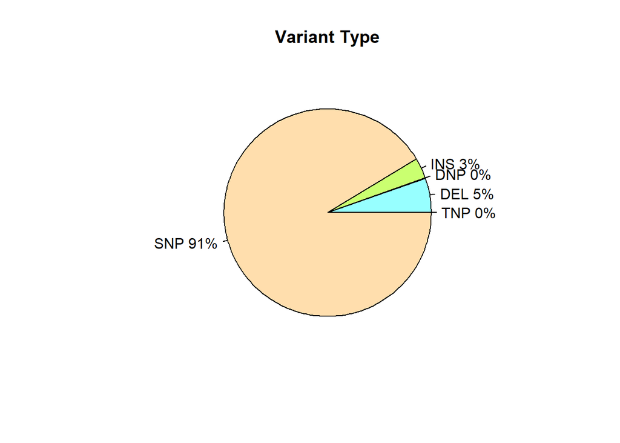

```r
# Pie Chart Variant type
w = table(sub_CCLE_mutations$Variant_Type)
t = as.data.frame(w)

slices <- t$Freq
lbls <- t$Var1
pct <- round(slices/sum(slices)*100)
lbls <- paste(lbls, pct) # add percents to labels
lbls <- paste(lbls,"%",sep="") # ad % to labels
pie(slices,labels = lbls, col = c("darkslategray1", "coral", "darkolivegreen1", "navajowhite"),
   main="Variant Type")
```

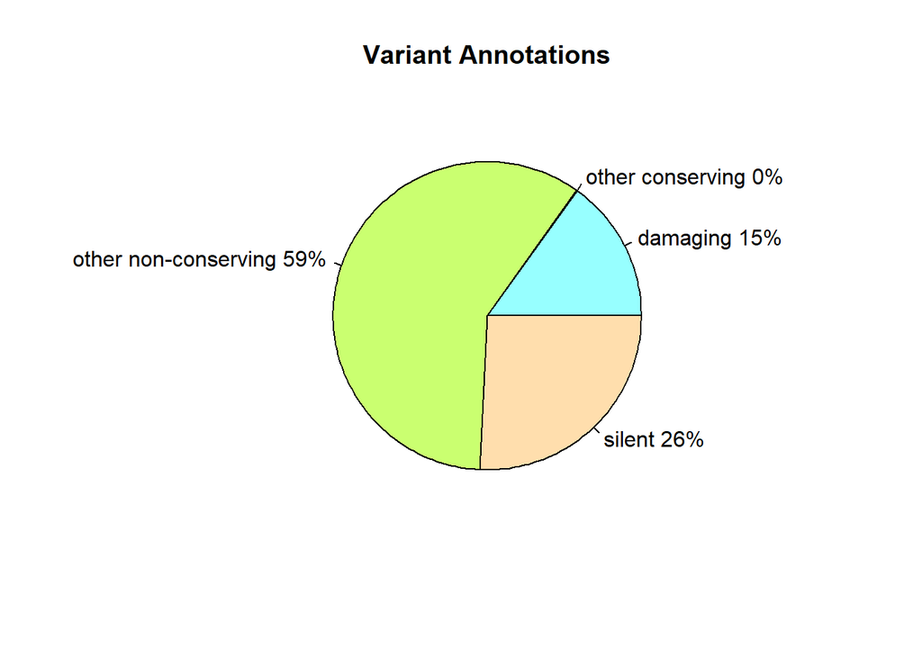

```r
w2 = table(sub_CCLE_mutations$Variant_annotation)
t2 = as.data.frame(w2)

# Pie Chart Variant annotation
slices <- t2$Freq
lbls <- t2$Var1
pct <- round(slices/sum(slices)*100)
lbls <- paste(lbls, pct) # add percents to labels
lbls <- paste(lbls,"%",sep="") # ad % to labels
pie(slices,labels = lbls, col = c("darkslategray1", "coral", "darkolivegreen1", "navajowhite"),
   main="Variant Annotations")
```

```r
#Teste a homogeneidade das variâncias
leveneTest(sub_sample_info$age ~ sub_sample_info$sex)
```

```
## Levene's Test for Homogeneity of Variance (center = median)
##        Df F value Pr(>F)
## group   2  0.8271  0.438
##       414
```

```r
#There is no evidence to suggest that the variance across groups is statistically significantly different

# Compute the analysis of variance
res.aov <- aov(sub_sample_info$age ~ sub_sample_info$sex)

# Summary of the analysis
summary(res.aov)
```

```
##                      Df Sum Sq Mean Sq F value Pr(>F)
## sub_sample_info$sex   2    542   270.8   0.826  0.438
## Residuals           414 135683   327.7
## 142 observations deleted due to missingness
```

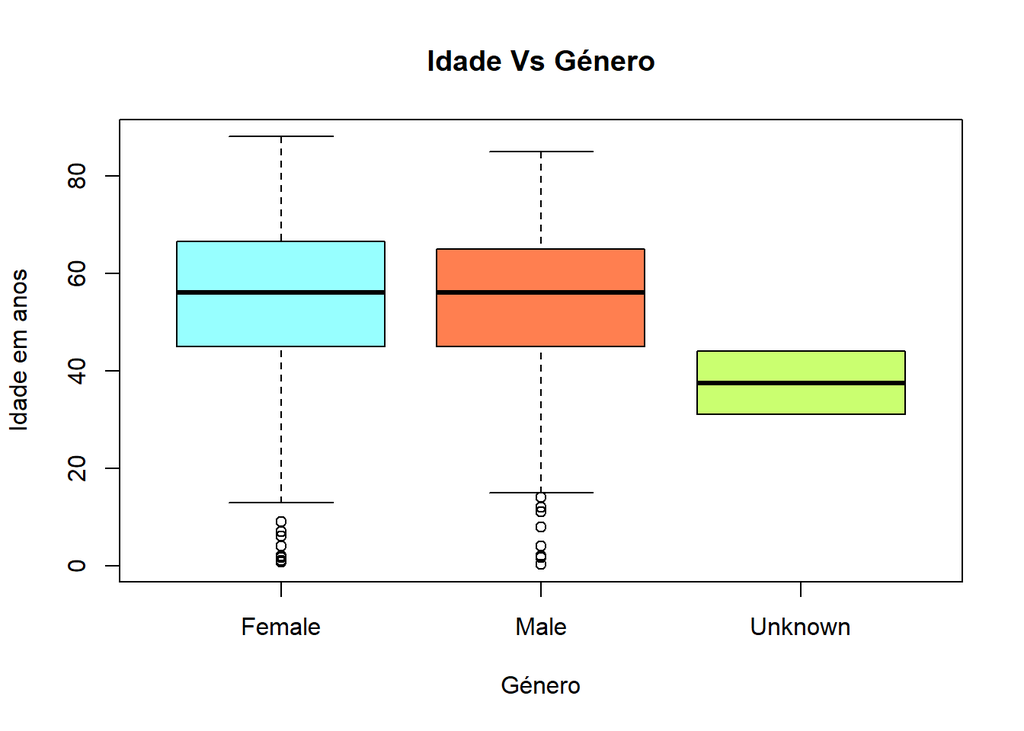

```r
#No differences

#Boxplot Age vs Sex
boxplot(age ~ sex, data = sub_sample_info, main = "Idade Vs Género", xlab = "Género", ylab = "Idade em anos", col = c("darkslategray1", "coral", "darkolivegreen1"))
```

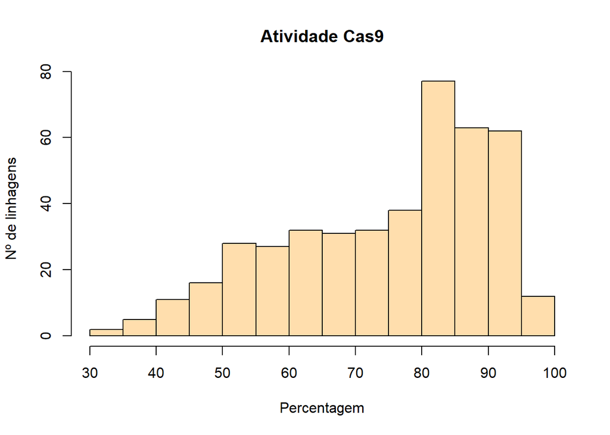

```r
#Histograma Cas9_Activity
hist(sub_sample_info$cas9_activity, main = "Atividade Cas9", xlab = "Percentagem", ylab = "Nº de linhagens", col = "navajowhite")
```

Foram construídos *piecharts* para a visualização das variáveis “Variant_Type” e “Variant_annotation” do *dataset* **sub_CCLE_mutations**.  
Foi realizada uma análise **ANOVA** entre as variáveis “age” e “sex”. A **normalidade** de distribuição **foi assumida** pelo teorema do limite central, e a homogeneidade das variâncias, não havendo evidência que as variâncias entre grupos fossem estatísticamente diferentes, A análise **ANOVA** revelou que **não existem** diferenças significas entre as médias dos grupos da variável “sex” para os valores de “age”, como comprovado pela análise do *boxplot* associado.  
Constuiu-se também um histograma para a visualização da variável “cas9_activity” do *dataset* **sub_sample_info**, observando-se que occore um maior número de linhagens entre as $80-95\%$.

# 5 Expressão diferencial

## 5.1 Preparação dos metadados

Para efetuar uma análise de expressão diferencial sobre o *dataset* **raw_counts**, o primeiro passo tomado foi selecionar os metadados que iriam permitir essa análise. Para este primeiro esforço foram selecionados como metadados a variável “primary_or_metastasis” do *dataset* **sample_info** e foi gerada uma nova variável (“mut_counts”) que corresponde à contagem do número de mutações associadas a cada linhagem cancerígena, tendo esta informação sido obtida com recurso à manipulação da variável “DepMap_ID” do *dataset* **CCLE_mutations**.

```r
#1º Metadado --> quantificar as mutações de cada linhagem
#agrupar pelas linhagens celulares
mutation_counts  <- CCLE_mutations %>%
  group_by(DepMap_ID) %>%
  summarise(mut_freq = length(DepMap_ID))

#Análise descritiva da coluna mut_freq
descr(mutation_counts$mut_freq)
```

```
## Descriptive Statistics
## mutation_counts$mut_freq
## N: 1747
##
##                     mut_freq
## ----------------- ----------
##              Mean     737.43
##           Std.Dev    2163.49
##               Min      16.00
##                Q1     249.00
##            Median     367.00
##                Q3     577.00
##               Max   66665.00
##               MAD     207.56
##               IQR     326.50
##                CV       2.93
##          Skewness      19.42
##       SE.Skewness       0.06
##          Kurtosis     525.69
##           N.Valid    1747.00
##         Pct.Valid     100.00
```

```r
#Fazer a discritização dos dados em 3 níveis (low, medium, high) de acordo com a frequência
mutation_counts$mut_counts <- discretize(mutation_counts$mut_freq, method = "frequency", breaks = 3, labels = c("Low", "Medium", "High"))

#colocar as linhagens como row names
mutation_counts <- mutation_counts %>% remove_rownames %>% column_to_rownames(var="DepMap_ID")

#ver descrição do data.frame e distribução por cada nível
str(mutation_counts)
```

```
## 'data.frame':    1747 obs. of  2 variables:
##  $ mut_freq  : int  308 180 207 271 288 220 408 379 438 352 ...
##  $ mut_counts: Factor w/ 3 levels "Low","Medium",..: 2 1 1 1 1 1 2 2 2 2 ...
##   ..- attr(*, "discretized:breaks")= num [1:4] 16 290 477 66665
##   ..- attr(*, "discretized:method")= chr "frequency"
```

```r
freq(mutation_counts$mut_counts)
```

```
## Frequencies
## mutation_counts$mut_counts
## Type: Factor
##
##                Freq   % Valid   % Valid Cum.   % Total   % Total Cum.
## ------------ ------ --------- -------------- --------- --------------
##          Low    582     33.31          33.31     33.31          33.31
##       Medium    581     33.26          66.57     33.26          66.57
##         High    584     33.43         100.00     33.43         100.00
##         <NA>      0                               0.00         100.00
##        Total   1747    100.00         100.00    100.00         100.00
```

```r
#2º Metadado - Cancro primário ou metástase
#Criar o data.frame com as linhagens e o tipo de cancro associada (primário (prim) e metástase (met))
prim_met = data.frame(label = sample_info$DepMap_ID, type = sample_info$primary_or_metastasis)

#Definir a variável "type" como um factor
prim_met$type <- as.factor(prim_met$type)

#Verificar a distribuição das linhagens por tipo de cancro
freq(prim_met$type)
```

```
## Frequencies
## prim_met$type
## Type: Factor
##
##                    Freq   % Valid   % Valid Cum.   % Total   % Total Cum.
## ---------------- ------ --------- -------------- --------- --------------
##       Metastasis    498     43.42          43.42     27.50          27.50
##          Primary    649     56.58         100.00     35.84          63.34
##             <NA>    664                              36.66         100.00
##            Total   1811    100.00         100.00    100.00         100.00
```

```r
#transforma a variàvel label em row names, ou seja as linhagens
prim_met <- prim_met %>% remove_rownames %>% column_to_rownames(var="label")

#Criar a matriz com os nossos metadados ou seja "cruzar" o nº de mutações com o tipo de cancro de acordo com as linhagens
metadados <- merge(mutation_counts, prim_met, by=0, all=TRUE)

#Omitir as linhagens que têm NA associados
clean_metadados <- na.omit(metadados)
dfSummary(clean_metadados)
```

```
## Data Frame Summary
## clean_metadados
## Dimensions: 1125 x 4
## Duplicates: 0
##
## ---------------------------------------------------------------------------------------------------------------
## No   Variable      Stats / Values              Freqs (% of Valid)    Graph                 Valid      Missing
## ---- ------------- --------------------------- --------------------- --------------------- ---------- ---------
## 1    Row.names     1. ACH-000001                  1 ( 0.1%)                                1125       0
##      [AsIs]        2. ACH-000002                  1 ( 0.1%)                                (100.0%)   (0.0%)
##                    3. ACH-000006                  1 ( 0.1%)
##                    4. ACH-000007                  1 ( 0.1%)
##                    5. ACH-000009                  1 ( 0.1%)
##                    6. ACH-000011                  1 ( 0.1%)
##                    7. ACH-000012                  1 ( 0.1%)
##                    8. ACH-000013                  1 ( 0.1%)
##                    9. ACH-000014                  1 ( 0.1%)
##                    10. ACH-000015                 1 ( 0.1%)
##                    [ 1115 others ]             1115 (99.1%)          IIIIIIIIIIIIIIIIIII
##
## 2    mut_freq      Mean (sd) : 812.5 (2313)    672 distinct values   :                     1125       0
##      [integer]     min < med < max:                                  :                     (100.0%)   (0.0%)
##                    16 < 421 < 66665                                  :
##                    IQR (CV) : 356 (2.8)                              :
##                                                                      :
##
## 3    mut_counts    1. Low                      270 (24.0%)           IIII                  1125       0
##      [factor]      2. Medium                   389 (34.6%)           IIIIII                (100.0%)   (0.0%)
##                    3. High                     466 (41.4%)           IIIIIIII
##
## 4    type          1. Metastasis               483 (42.9%)           IIIIIIII              1125       0
##      [factor]      2. Primary                  642 (57.1%)           IIIIIIIIIII           (100.0%)   (0.0%)
## ---------------------------------------------------------------------------------------------------------------
```

```r
#Datasets para análise diferencial
meta_expression <- raw_counts %>% filter(raw_counts$DepMap_ID %in% clean_metadados$Row.names)

meta_intersect <- clean_metadados %>% filter(clean_metadados$Row.names %in% meta_expression$DepMap_ID)

#Comprovativo do cruzamento
dim(meta_expression)
```

```
## [1]  1020 52440
```

```r
dim(meta_intersect)
```

```
## [1] 1020    4
```

Para gerar a variável “mut_counts” foram contadas o número de linhas associados ao mesmo “DepMap_ID”, gerando a variável “mut_freq”. Esta variável numérica foi de seguida convertida numa variável fatorial com recurso a função *discretize* do package *arules*. Esta discretização foi efetuada por frequência, tendo sido pedido à função para gerar $3$ níveis. Isto resultou em 3 níveis com aproximadamente o mesmo número de indivíduos, que classificamos como “Low”, “Medium” e “High”, sendo isto referente a quantidade relativa de mutações associadas a cada linhagem celular.  
Foi também definida a variável “type” que foi extraída diretamente a partir da variável “primary_or_metastasis” do *dataset* **sample_info**. Esta variável possuia *NA*, que foram omitidos devido à impossibilidade de imputar dados fatoriais.  
Estas duas variáveis foram combinadas num *dataset*, **clean_metadados** (sem *NA*), que foi cruzado com o *dataset* **raw_counts**, obtendo-se o *dataset* cruzado de expressão **meta_expression**. Os metadados foram também por sua vez cruzados com este último *dataset* e obteve-se o *dataset* cruzado de metadados **meta_intersect**.  
Em suma, os *datasets* **meta_expression** e **meta_intersect** possuem os dados de expressão e de metadados respetivamente para as mesma linhagens celulares, sendo a partir destes que iremos efetuar a análise de expressão diferencial. Não se optou por partir dos datasets anteriormente cruzados (**sub_raw_counts**, **sub_CCLE_mutations**, **sub_sample_info**, **sub_drug_response**), pois como o dataset **drug_response** não será utilizado, e este era o mais limitante nas filtragens anteriores, optou-se por maximizar o número de linhagens celulares passíveis de serem analisadas.

## 5.2 Análise Univariada sobre os metadados

Foi efetuada uma exploração univariada para a caracterização dos metadados.

```r
#Estatistica descritiva
descr(mutation_counts$mut_freq)
```

```
## Descriptive Statistics
## mutation_counts$mut_freq
## N: 1747
##
##                     mut_freq
## ----------------- ----------
##              Mean     737.43
##           Std.Dev    2163.49
##               Min      16.00
##                Q1     249.00
##            Median     367.00
##                Q3     577.00
##               Max   66665.00
##               MAD     207.56
##               IQR     326.50
##                CV       2.93
##          Skewness      19.42
##       SE.Skewness       0.06
##          Kurtosis     525.69
##           N.Valid    1747.00
##         Pct.Valid     100.00
```

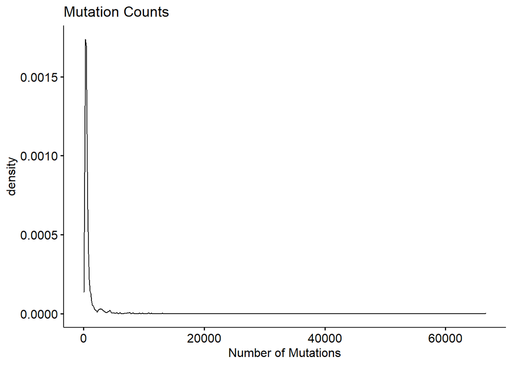

```r
#Density plot
ggdensity(clean_metadados$mut_freq,
          main = "Mutation Counts",
          xlab = "Number of Mutations")
```

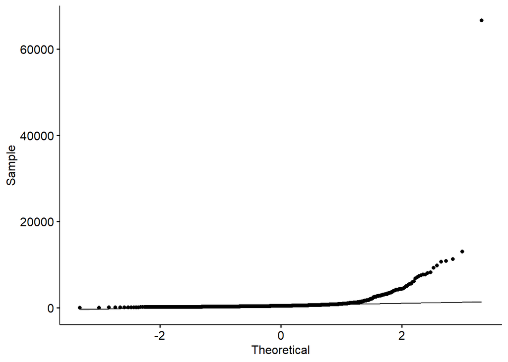

```r
#Q-Q plot
ggqqplot(clean_metadados$mut_freq)
```

```r
#Claramente não normal

#Shapiro-test - Normalidade
shapiro.test(clean_metadados$mut_freq)
```

```
##
##  Shapiro-Wilk normality test
##
## data:  clean_metadados$mut_freq
## W = 0.18291, p-value < 2.2e-16
```

```r
#Não é normal

#Homogeneidade de variancias
leveneTest(clean_metadados$mut_freq ~ clean_metadados$type)
```

```
## Levene's Test for Homogeneity of Variance (center = median)
##         Df F value Pr(>F)
## group    1  0.1588 0.6903
##       1123
```

```r
#There is no evidence to suggest that the variance across groups is statistically significantly different

leveneTest(clean_metadados$mut_freq ~ clean_metadados$mut_counts)
```

```
## Levene's Test for Homogeneity of Variance (center = median)
##         Df F value   Pr(>F)
## group    2  22.523 2.57e-10 ***
##       1122
## ---
## Signif. codes:  0 '***' 0.001 '**' 0.01 '*' 0.05 '.' 0.1 ' ' 1
```

```r
#There is evidence to suggest that the variance across groups is statistically significantly different

##Teste as médias
#Teste para dois grupos - freq vs type
wilcox.test(clean_metadados$mut_freq ~ clean_metadados$type,
                   exact = FALSE)
```

```
##
##  Wilcoxon rank sum test with continuity correction
##
## data:  clean_metadados$mut_freq by clean_metadados$type
## W = 160234, p-value = 0.3359
## alternative hypothesis: true location shift is not equal to 0
```

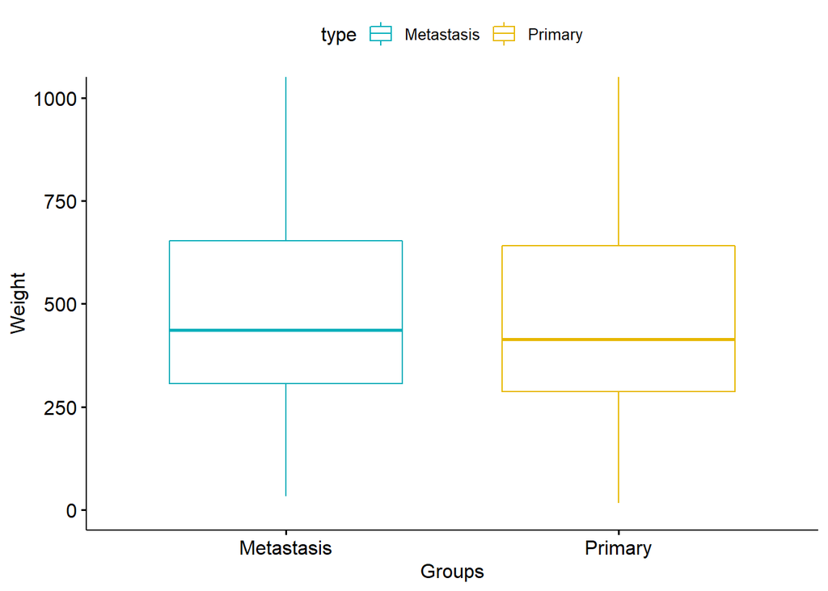

```r
#Box plot - types
p<-ggboxplot(clean_metadados, x = "type", y = "mut_freq",
          color = "type", palette = c("#00AFBB", "#E7B800"),
          ylab = "Weight", xlab = "Groups")

ggpar(p, ylim = c(0,1000),)
```

```r
#Kruskal-wallis - freq vs counts
res.krusk <- kruskal.test(clean_metadados$mut_freq ~ clean_metadados$mut_counts)
res.krusk
```

```
##
##  Kruskal-Wallis rank sum test
##
## data:  clean_metadados$mut_freq by clean_metadados$mut_counts
## Kruskal-Wallis chi-squared = 982.11, df = 2, p-value < 2.2e-16
```

```r
pairwise.wilcox.test(clean_metadados$mut_freq, clean_metadados$mut_counts,
                     p.adjust.method = "BH")
```

```
##
##  Pairwise comparisons using Wilcoxon rank sum test with continuity correction
##
## data:  clean_metadados$mut_freq and clean_metadados$mut_counts
##
##        Low    Medium
## Medium <2e-16 -
## High   <2e-16 <2e-16
##
## P value adjustment method: BH
```

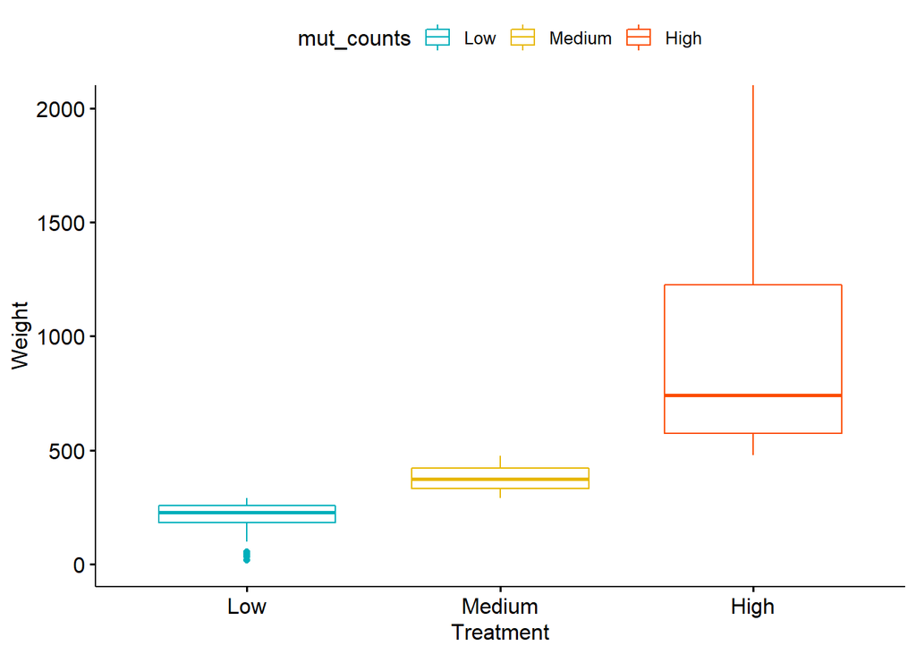

```r
#Box plot - counts
p2<-ggboxplot(clean_metadados, x = "mut_counts", y = "mut_freq",
          color = "mut_counts", palette = c("#00AFBB", "#E7B800", "#FC4E07"),
          ylab = "Weight", xlab = "Treatment")

ggpar(p2, ylim = c(0,2000),)
```

Conclui-se que a variável “mut_freq”, possui uma *média* de $737,43$ e um *desvio-padrão* de $2163,49$, com um mínimo de $16$ e um máximo de $66665$, com um *coeficiente de variação* de $2,93\%$. Com recurso a um *Q-Q plot* e a um *teste de Shapiro-Wilk*, verificou-se que esta variável **não se encontra normalmente distribuída**. A **homogeneidade das variâncias** foi averiguada com recurso ao *teste de Levene*, tendo-se verificado que quando agrupado a variável “mut_freq” pela variável “type” **não existia evidência estatística** para sugerir **diferenças ente a variânca inter-grupos**; o **oposto** verificou-se quando se repetiu a análise coma a variável “mut_counts”.  
Analisando as médias, devido às variáveis **não cumprirem** as assumções da *ANOVA* e do *t-test* (normalidade de distribuição, homogeneidade de variância), optou-se por alternativas não-paramétricas, na forma do *teste de Wilcox* para testar a variância da variável “mut_freq” quando agrupada pela variável “type” (apenas dois grupos), e no *teste de Kruskal-Wallis* para testar a variância da variável “mut_freq” quando agrupada pela variável “mut_counts” (3 grupos).  
Conclui-se que **não se observam diferenças significativas** entre os fatores da variável “type” relativamente a “mut_freq”, e que o **oposto** se verificou entre os fatores da variável “mut_counts” relativamente a “mut_freq”, tendo sido efetuadas comparações múltiplas *a posteriori* com o *teste de Wilcox pairwise*, sendo *todas as comparações entre fatores significativas*. Estas conclusões foram verificadas de forma gráfica com recurso aos boxplots acima apresentados.

## 5.3 Gerar matriz de expressão

O *dataset* **meta_expression**, acima explicado, teve a variável “DepMap_ID” definida com os seus *rownames* e foi ordenada e transposta originando a matriz de expressão **exp_matrix** usada para a análise de expressão diferencial.

```r
#Preparar para transpor dados de expressão/Reservar informação sobre os genes
meta_expression <- meta_expression %>% remove_rownames %>% column_to_rownames(var="DepMap_ID")

#Ordenar os id das linhagens
meta_expression_ordered <- meta_expression[ order(row.names(meta_expression)), ]

#Transpor a matrix de expressão
exp_matrix <- t(meta_expression_ordered)
```

## 5.4 Criação das anotações

Com recurso ao package *org.Hs.eg.db* e aos “ENSEMBLIDs” extraídos dos *rownames* da matriz **exp_matrix** foi possível extrair alguma anotação sobre os genes nesta presentes, mais concretamente o seu “ENTREZID”, “HUGO SYMBOL” e “GENENAME”. Foram removidos da matriz **exp_matrix** todos os genes que não possuiam anotação associada.

```r
ensembl_ids <- sub("\\).*", "", sub(".*\\(", "", row.names(exp_matrix)))

ann <- select(org.Hs.eg.db,keys=ensembl_ids,keytype='ENSEMBL',columns=c('ENTREZID',"ENSEMBL","SYMBOL","GENENAME"))
# Remove duplicated rows based on Ensembl_id
ann <- ann %>% distinct(ENSEMBL, .keep_all = TRUE)

#Número de gene com anotação
sum(is.na(ann$ENTREZID))
```

```
## [1] 21800
```

```r
#Lista de genes sem anotação
noann<-subset(ann,is.na(ann$ENTREZID))

dim(exp_matrix)
```

```
## [1] 52439  1020
```

```r
#Remover genes da matrix de expressao sem anotação
row.names(exp_matrix) <- ensembl_ids

exp_matrix <- exp_matrix[ !(rownames(exp_matrix) %in% noann$ENSEMBL), ]

#Remover genes da dataframe da anotação sem anotação
ann <- ann[ !(ann$ENSEMBL %in% noann$ENSEMBL), ]

dim(exp_matrix)
```

```
## [1] 30639  1020
```

```r
dim(ann)
```

```
## [1] 30639     4
```

## 5.5 Análise de expressão diferencial

Foi efetuada a análise de expressão diferencial para **3 metadados específicos**: para a variável “type”, para a variável “mut_counts” e para uma combinação destas. Para efetuar esta análise começou-se por carregar a matriz de contagens **exp_matrix** num objeto *DGEList*. De seguida foram carregadas as anotações neste objeto, a matriz de **design** para o metadado a ser usado foi construída e foram definidos os contrastes a analisar (**contrast**). A seguir, foi efetuada uma filtragem das contagens com baixos valores de expressão com recurso a função *filterByExpr* do package *edgeR*, sendo aqui fornecida a matriz de **design**. Foi verificado o tamanho das *libraries* associadas às contagens e calculados os fatores de normalização. O package *limma* foi aqui usado sobre a forma de *limma voom* para transformar as contagens em valores $log2$ normalizados, sendo obtido um gráfico de média-variância. Seguidamente a expressão diferencial foi testada utilizando *limma trend* seguindo a seguinte pipeline:

- Ajuste do modelo (*fit*) a partir do objeto voom (**v**);
- Fornecimento dos contrastes ao modelo (*fit_cont*);
- Gerar as estatísticas (“t-statistics”, “p-values”) (*EBayes*);
- Identificação de genes diferencialmente expressos (*summa.fit*) com apresentação de uma tabela com o top 10 genes diferencialmente expressos para um contraste a escolha (*topTable*) e visualização destes resultados de forma gráfica (*plotMD* e *volcanoplot*).

Este último ponto foi repetido após a filtragem dos resultados de expressão com recurso a função *treat*, tendo se definido um valor de *cut-off* de $log2(1.2)$, devido a este ser o mínimo considerado para relevancia biológica. Por último, com recurso à anotação, foi realizado com a função *goana* do package *limma* a análise das ontologias genéticas que se encontravam mais representadas nos genes diferencialmente expressos resultantes da análise anterior.

### Cancer_type

```r
#Carregar no EdgeR
y <- DGEList(counts = exp_matrix)

#Carregar anotação dos genes
y$genes <- ann

#Design for mutation types
Cancer_type <- meta_intersect$type

Mutation_count <- meta_intersect$mut_counts

design = model.matrix(~0+Cancer_type, data = y$samples)
colnames(design) <- levels(Cancer_type)
design
```

[output not shown]

[output cut: 971 more lines]

[output not shown]

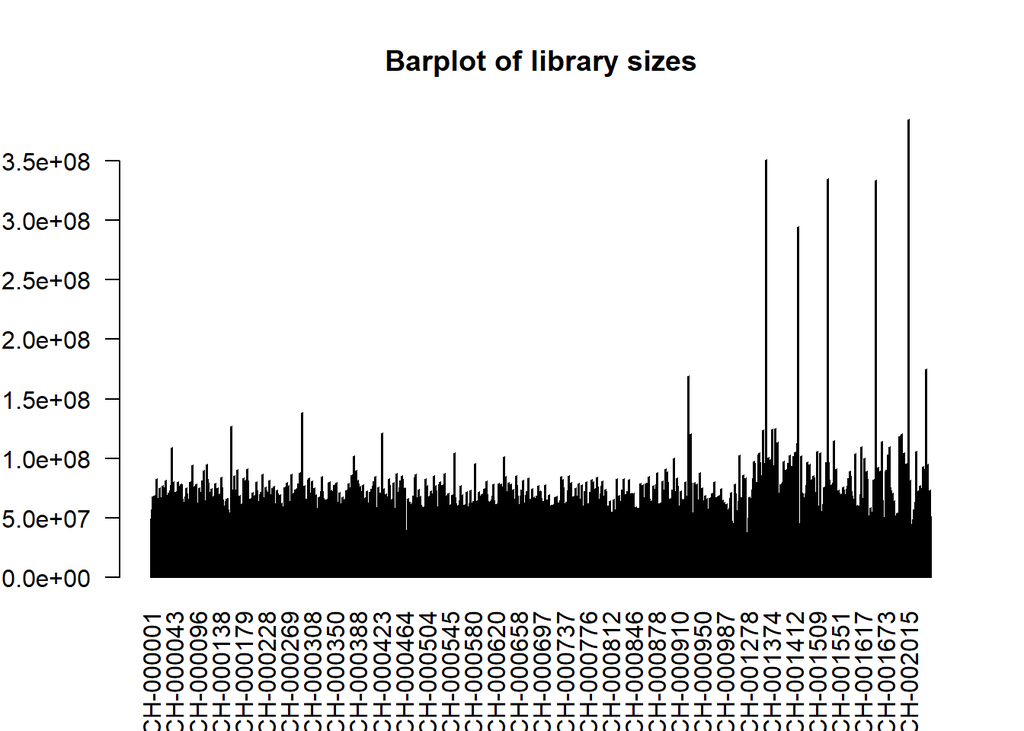

```r
#Make contrasts
contrast <- makeContrasts(Metastasis-Primary, levels=design)

keep <- filterByExpr(y, design)
y <- y[keep, , keep.lib.sizes=FALSE]

barplot(y$samples$lib.size,names=colnames(y),las=2)
# Add a title to the plot
title("Barplot of library sizes")
```

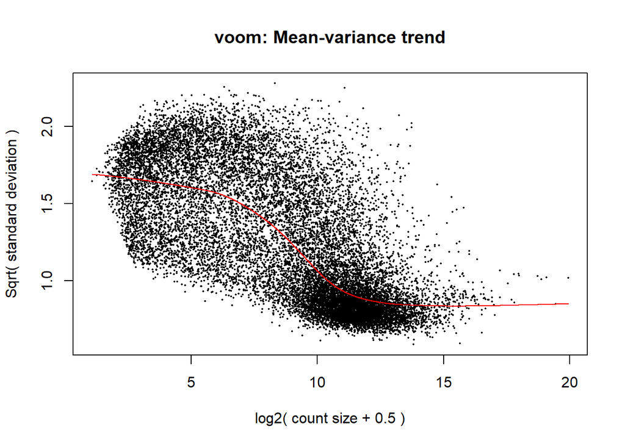

```r
#Normalization for composition bias
y <- calcNormFactors(y)


#Start limma voom pipeline
par(mfrow=c(1,1))
v <- voom(y,design,plot = TRUE)
```

```r
#Limma Trend
fit <- lmFit(v, design)

fit.cont <- contrasts.fit(fit, contrast)

fit.cont <- eBayes(fit.cont)

dim(fit.cont)
```

```
## [1] 17049     1
```

```r
dim(y$genes)
```

```
## [1] 17049     4
```

```r
summa.fit <- decideTests(fit.cont)

summary(summa.fit)
```

```
##        Metastasis - Primary
## Down                   1488
## NotSig                13746
## Up                     1815
```

```r
topTable(fit.cont, coef=1)
```

```
##                         ENSEMBL ENTREZID SYMBOL
## ENSG00000277363 ENSG00000277363    80725 SRCIN1
## ENSG00000170500 ENSG00000170500   164832 LONRF2
## ENSG00000125347 ENSG00000125347     3659   IRF1
## ENSG00000064666 ENSG00000064666     1265   CNN2
## ENSG00000084710 ENSG00000084710    22979  EFR3B
## ENSG00000171522 ENSG00000171522     5734 PTGER4
## ENSG00000165716 ENSG00000165716   138311 DIPK1B
## ENSG00000134470 ENSG00000134470     3601 IL15RA
## ENSG00000231925 ENSG00000231925     6892  TAPBP
## ENSG00000119523 ENSG00000119523    85365   ALG2
##                                                          GENENAME      logFC
## ENSG00000277363                  SRC kinase signaling inhibitor 1  1.1778416
## ENSG00000170500 LON peptidase N-terminal domain and ring finger 2  1.8764666
## ENSG00000125347                    interferon regulatory factor 1 -0.7169977
## ENSG00000064666                                        calponin 2 -0.8391365
## ENSG00000084710                                    EFR3 homolog B  1.3286620
## ENSG00000171522                        prostaglandin E receptor 4 -1.2257350
## ENSG00000165716                divergent protein kinase domain 1B  0.9425443
## ENSG00000134470             interleukin 15 receptor subunit alpha -1.2873596
## ENSG00000231925                               TAP binding protein -0.4822179
## ENSG00000119523            ALG2 alpha-1,3/1,6-mannosyltransferase -0.2772753
##                  AveExpr         t      P.Value    adj.P.Val        B
## ENSG00000277363 1.577204  8.141373 1.130480e-15 1.927355e-11 24.79295
## ENSG00000170500 1.040814  7.829679 1.219442e-14 1.039513e-10 22.46640
## ENSG00000125347 4.659556 -7.707073 3.040813e-14 1.296070e-10 21.64372
## ENSG00000064666 6.851843 -7.714851 2.870618e-14 1.296070e-10 21.51654
## ENSG00000084710 1.362372  7.155600 1.588244e-12 5.415593e-09 17.86729
## ENSG00000171522 1.330535 -7.094587 2.422061e-12 6.882286e-09 17.40914
## ENSG00000165716 2.222895  6.848296 1.288445e-11 2.639444e-08 15.92622
## ENSG00000134470 1.652664 -6.820765 1.548152e-11 2.639444e-08 15.68692
## ENSG00000231925 6.836791 -6.865460 1.148691e-11 2.639444e-08 15.64934
## ENSG00000119523 5.174120 -6.826720 1.487951e-11 2.639444e-08 15.51418
```

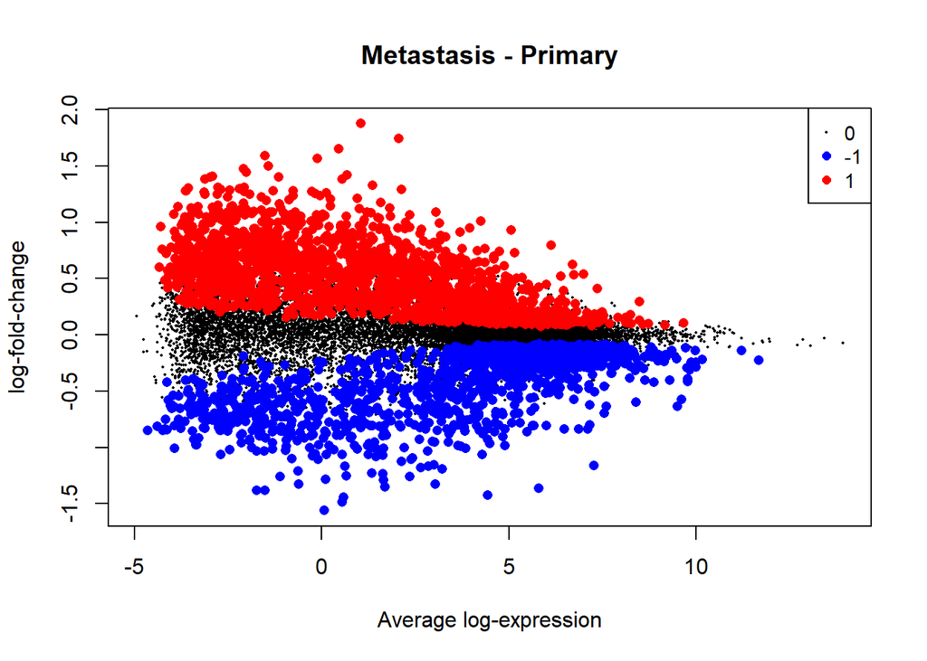

```r
#Genome - Wide plots
plotMD(fit.cont,coef=1,status=summa.fit[,"Metastasis - Primary"], values = c(-1, 1), hl.col=c("blue","red"))
```

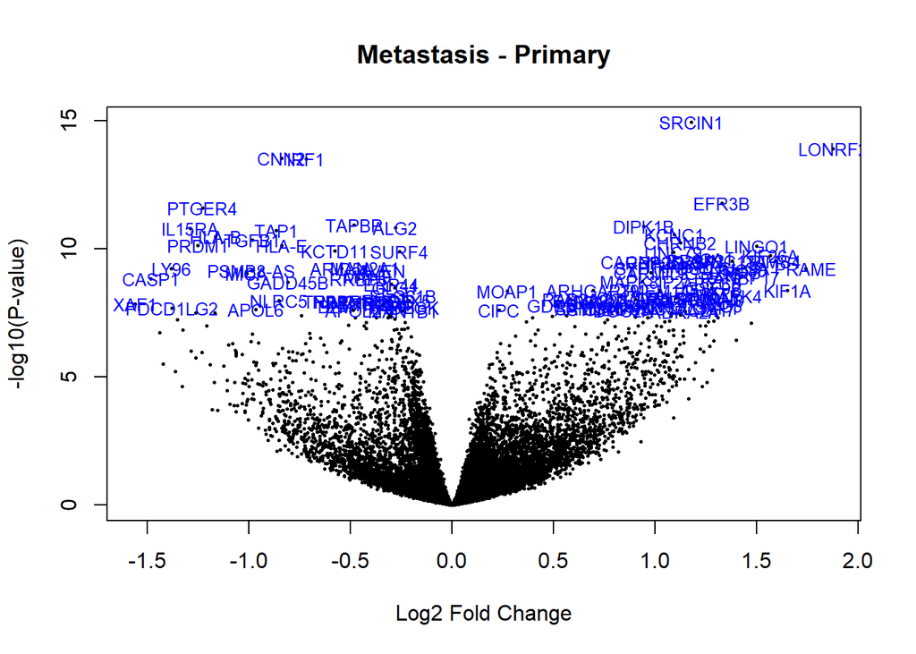

```r
volcanoplot(fit.cont,coef=1,highlight=100,names=y$genes$SYMBOL, main="Metastasis - Primary")
```

```r
glXYPlot(x=fit.cont$coefficients[,1], y=fit.cont$lods[,1],
         xlab="logFC", ylab="B", main="Metastasis - Primary",
         counts=v$E, groups=Cancer_type, status=summa.fit[,1],
         anno=fit.cont$genes, side.main="ENSEMBL", folder="cancer_type_volcano", html = "cancer_type_volcano")


#Testing relative to a threshold - TREAT
fit.treat <- treat(fit.cont,lfc=log2(1.2))

topTreat(fit.treat, coef=1)
```

```
##                         ENSEMBL ENTREZID SYMBOL
## ENSG00000170500 ENSG00000170500   164832 LONRF2
## ENSG00000277363 ENSG00000277363    80725 SRCIN1
## ENSG00000084710 ENSG00000084710    22979  EFR3B
## ENSG00000171522 ENSG00000171522     5734 PTGER4
## ENSG00000134470 ENSG00000134470     3601 IL15RA
## ENSG00000169783 ENSG00000169783    84894 LINGO1
## ENSG00000066735 ENSG00000066735    26153 KIF26A
## ENSG00000185686 ENSG00000185686    23532  PRAME
## ENSG00000101098 ENSG00000101098   140730  RIMS4
## ENSG00000064666 ENSG00000064666     1265   CNN2
##                                                          GENENAME      logFC
## ENSG00000170500 LON peptidase N-terminal domain and ring finger 2  1.8764666
## ENSG00000277363                  SRC kinase signaling inhibitor 1  1.1778416
## ENSG00000084710                                    EFR3 homolog B  1.3286620
## ENSG00000171522                        prostaglandin E receptor 4 -1.2257350
## ENSG00000134470             interleukin 15 receptor subunit alpha -1.2873596
## ENSG00000169783    leucine rich repeat and Ig domain containing 1  1.5014033
## ENSG00000066735                         kinesin family member 26A  1.5669379
## ENSG00000185686  PRAME nuclear receptor transcriptional regulator  1.7424568
## ENSG00000101098         regulating synaptic membrane exocytosis 4  1.5908673
## ENSG00000064666                                        calponin 2 -0.8391365
##                   AveExpr         t      P.Value    adj.P.Val
## ENSG00000170500  1.040814  6.732151 1.391762e-11 2.372815e-07
## ENSG00000277363  1.577204  6.323250 1.911119e-10 1.629134e-06
## ENSG00000084710  1.362372  5.739011 6.272580e-09 3.564707e-05
## ENSG00000171522  1.330535 -5.572137 1.609159e-08 6.858636e-05
## ENSG00000134470  1.652664 -5.427141 3.576200e-08 1.027395e-04
## ENSG00000169783 -1.424929  5.425124 3.615678e-08 1.027395e-04
## ENSG00000066735 -0.128156  5.357594 5.210730e-08 1.231716e-04
## ENSG00000185686  2.055490  5.312362 6.640807e-08 1.231716e-04
## ENSG00000101098 -1.517815  5.310498 6.707210e-08 1.231716e-04
## ENSG00000064666  6.851843 -5.296566 7.224565e-08 1.231716e-04
```

```r
res.treat <- decideTests(fit.treat)

summary(res.treat)
```

```
##        Metastasis - Primary
## Down                     74
## NotSig                16767
## Up                      208
```

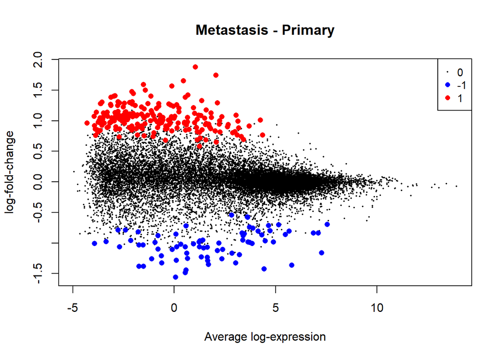

```r
plotMD(fit.treat,coef=1,status=res.treat[,"Metastasis - Primary"], values = c(-1, 1), hl.col=c("blue","red"))
```

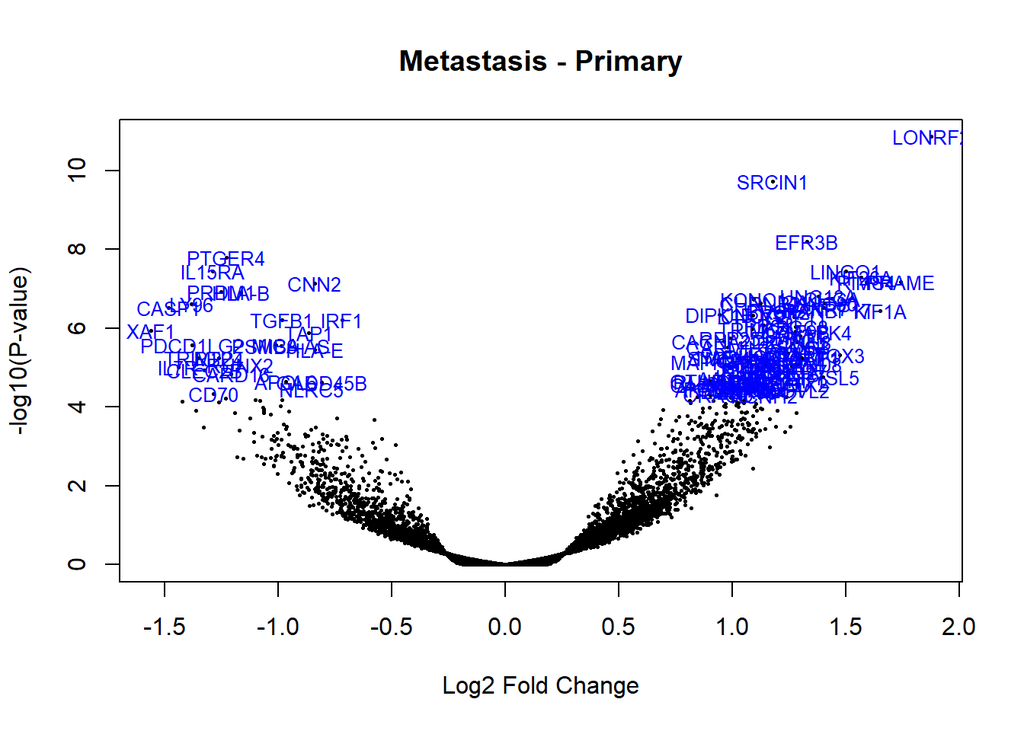

```r
volcanoplot(fit.treat,coef=1,highlight=100,names=y$genes$SYMBOL, main="Metastasis - Primary")
```

```r
glMDPlot(fit.treat, coef=1, counts=v$E, groups=Cancer_type,
         status=res.treat, side.main="ENSEMBL", main="Metastasis - Primary",
         folder="cancer_type_md", html = 'cancer_type_md')

#GO enrichment using goana on Treat results
go <- goana(fit.treat, coef="Metastasis - Primary", geneid = fit.treat$genes$ENTREZID, species = "Hs")
topGO(go, n=10)
```

```
##                                                  Term Ont    N Up Down
## GO:0051707                 response to other organism  BP 1055  6   37
## GO:0043207       response to external biotic stimulus  BP 1056  6   37
## GO:0009607                response to biotic stimulus  BP 1087  7   37
## GO:0006952                           defense response  BP 1181  9   36
## GO:0006955                            immune response  BP 1493  8   39
## GO:0098542         defense response to other organism  BP  782  5   30
## GO:0002376                      immune system process  BP 2326 16   45
## GO:0044419 interspecies interaction between organisms  BP 1682  6   39
## GO:0045087                     innate immune response  BP  639  4   27
## GO:0030424                                       axon  CC  550 38    2
##                    P.Up       P.Down
## GO:0051707 9.907030e-01 2.249828e-25
## GO:0043207 9.907819e-01 2.326268e-25
## GO:0009607 9.818152e-01 6.444575e-25
## GO:0006952 9.569924e-01 1.586991e-22
## GO:0006955 9.983569e-01 2.992119e-22
## GO:0098542 9.653960e-01 3.064327e-21
## GO:0002376 9.975737e-01 4.899600e-21
## GO:0044419 9.999777e-01 2.179677e-20
## GO:0045087 9.559925e-01 4.406477e-20
## GO:0030424 2.647833e-18 6.960889e-01
```

Para esta análise foram definidos como contrastes **Metastasis - Primary**. Da filtragem efetuada, permaneceram na análise $17049$ linhagens das $30639$ iniciais. A análise do gráfico de barras permite inferir que existem linhagens celulares com *library sizes* bastante superiores à média. O *output* gráfico do *limma voom* demonstra que ocorre uma dispersão dos pontos principalmente para valores de $log2 < 10$.  
Da análise de expressão diferencial resulta que, numa fase inicial e para o único contraste definido existem $1488$ **genes subexpressos** e $1815$ **sobrexpressos**. Isto pode ser analisado graficamente com recurso ao *MD plot* e ao *volcano plot*. Após a análise *TREAT* (*Testing relative to a threshold*) verificou-se que restaram $74$ **genes subexpressos** e $208$ **genes sobreexpressos**, o que também pode ser analisado graficamente com os gráficos já referidos. [^1]  
Por último, a análise sobre as ontologias genéticas permitiu inferir que se encontram **maioriatariamente subexpressos** genes associados ao processos biológicos de resposta imune e resposta a estímulos para o contraste referido. Isto é consistente com o conhecimento biológico sobre o comportamento de cancros metásticos, dados que ao longo da sua carcinogénese estes acumulam mutações que os levam a suprimir estas respostas de modo a proliferarem com mais facilidade pelo organismo.

Voltar à análise

### Mutation_count

```r
#Carregar no EdgeR
y <- DGEList(counts = exp_matrix)

#Carregar anotação dos genes
y$genes <- ann

#Design for mutation types
Cancer_type <- meta_intersect$type
Mutation_count <- meta_intersect$mut_counts

design = model.matrix(~0+Mutation_count, data = y$samples)
colnames(design) <- levels(Mutation_count)
design
```

[output not shown]

[output cut: 971 more lines]

```
## ACH-002062   0      0    1
## ACH-002065   0      1    0
## ACH-002066   0      1    0
## ACH-002067   0      1    0
## ACH-002069   0      1    0
## ACH-002446   0      1    0
## ACH-002508   0      0    1
## ACH-002509   0      0    1
## ACH-002510   0      0    1
## ACH-002511   1      0    0
## attr(,"assign")
## [1] 1 1 1
## attr(,"contrasts")
## attr(,"contrasts")$Mutation_count
## [1] "contr.treatment"
```

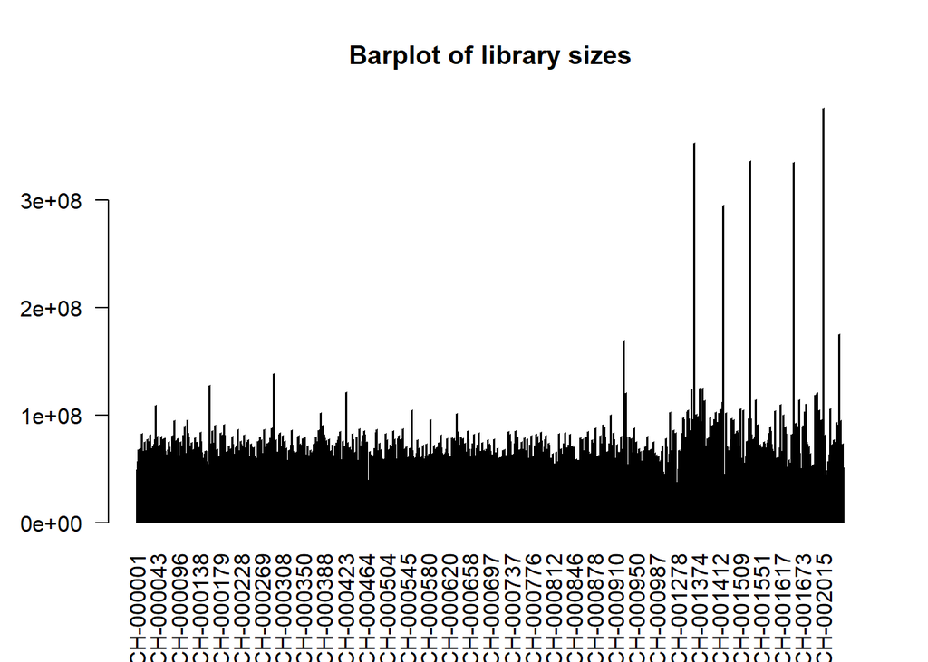

```r
#Make contrasts
contrast <- makeContrasts(MvsL=Medium-Low,
                          HvsM=High-Medium,
                          HvsL=High-Low
                          ,levels=design)

keep <- filterByExpr(y, design)
y <- y[keep, , keep.lib.sizes=FALSE]

barplot(y$samples$lib.size,names=colnames(y),las=2)
# Add a title to the plot
title("Barplot of library sizes")
```

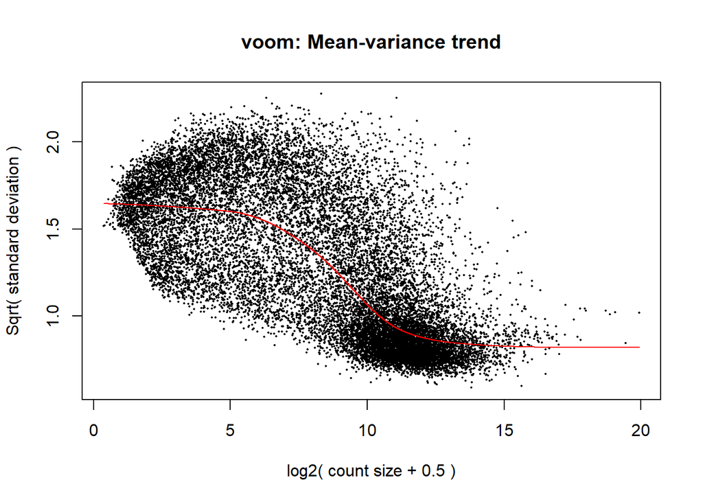

```r
#Normalization for composition bias
y <- calcNormFactors(y)


#Start limma voom pipeline
par(mfrow=c(1,1))

v <- voom(y,design,plot = TRUE)
```

```r
#Limma - Trend
fit <- lmFit(v, design)

fit.cont <- contrasts.fit(fit, contrast)

fit.cont <- eBayes(fit.cont, trend = F, robust = F)

summa.fit <- decideTests(fit.cont)

summary(summa.fit)
```

```
##         MvsL  HvsM  HvsL
## Down     553   841  3269
## NotSig 17063 16739 11571
## Up       690   726  3466
```

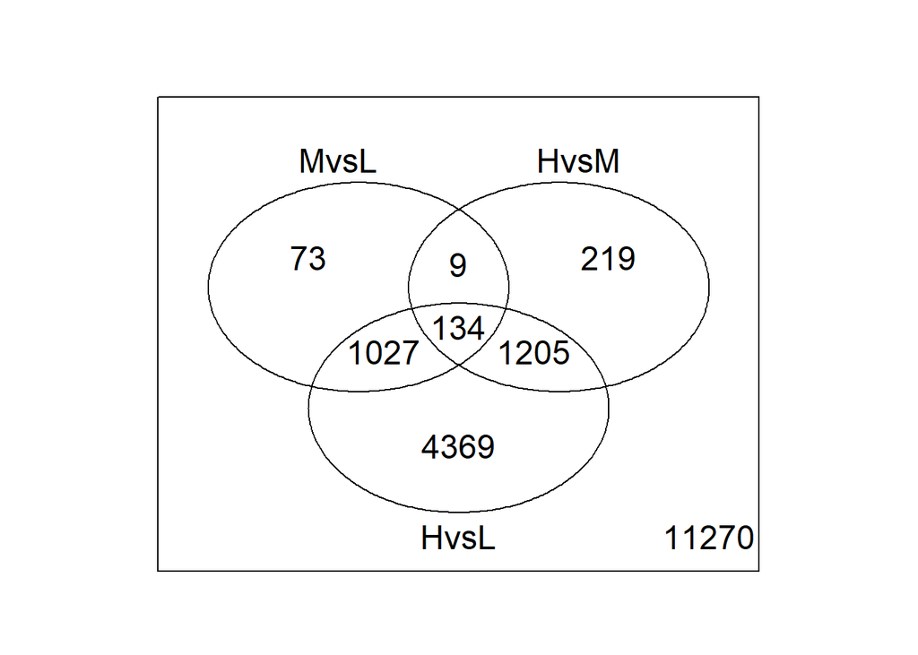

```r
vennDiagram(summa.fit)
```

```r
topTable(fit.cont, coef="HvsL")
```

```
##                         ENSEMBL ENTREZID    SYMBOL
## ENSG00000224271 ENSG00000224271   284930 LOC284930
## ENSG00000197172 ENSG00000197172     4105    MAGEA6
## ENSG00000221867 ENSG00000221867     4102    MAGEA3
## ENSG00000132274 ENSG00000132274    10346    TRIM22
## ENSG00000154175 ENSG00000154175    25890    ABI3BP
## ENSG00000268606 ENSG00000268606     4101    MAGEA2
## ENSG00000205634 ENSG00000205634   400932 LINC00898
## ENSG00000172638 ENSG00000172638    30008    EFEMP2
## ENSG00000183305 ENSG00000183305   266740   MAGEA2B
## ENSG00000169856 ENSG00000169856     3175   ONECUT1
##                                                              GENENAME     logFC
## ENSG00000224271                             uncharacterized LOC284930  2.513089
## ENSG00000197172                                 MAGE family member A6  3.717851
## ENSG00000221867                                 MAGE family member A3  3.867042
## ENSG00000132274                        tripartite motif containing 22 -2.469650
## ENSG00000154175                   ABI family member 3 binding protein -2.176098
## ENSG00000268606                                 MAGE family member A2  3.461953
## ENSG00000205634            long intergenic non-protein coding RNA 898  1.801097
## ENSG00000172638 EGF containing fibulin extracellular matrix protein 2 -1.774825
## ENSG00000183305                                MAGE family member A2B  3.192385
## ENSG00000169856                                    one cut homeobox 1  1.880362
##                     AveExpr         t      P.Value    adj.P.Val        B
## ENSG00000224271 -3.35920463 10.645557 3.613607e-25 6.615070e-21 45.57754
## ENSG00000197172  0.08835840  9.369801 4.518679e-20 3.533023e-16 34.53986
## ENSG00000221867  0.56752939  9.341348 5.789942e-20 3.533023e-16 34.34131
## ENSG00000132274  1.68023744 -9.037447 7.865898e-19 2.407407e-15 32.01182
## ENSG00000154175  0.02837394 -9.038843 7.773479e-19 2.407407e-15 31.88104
## ENSG00000268606 -1.39304852  9.037078 7.890552e-19 2.407407e-15 31.71401
## ENSG00000205634 -4.75604969  8.944857 1.717101e-18 4.490464e-15 30.89099
## ENSG00000172638  2.25579067 -8.794159 6.031243e-18 1.168585e-14 30.04045
## ENSG00000183305 -2.09832915  8.822431 4.771282e-18 1.091789e-14 29.96304
## ENSG00000169856 -3.89054517  8.787298 6.383617e-18 1.168585e-14 29.65147
```

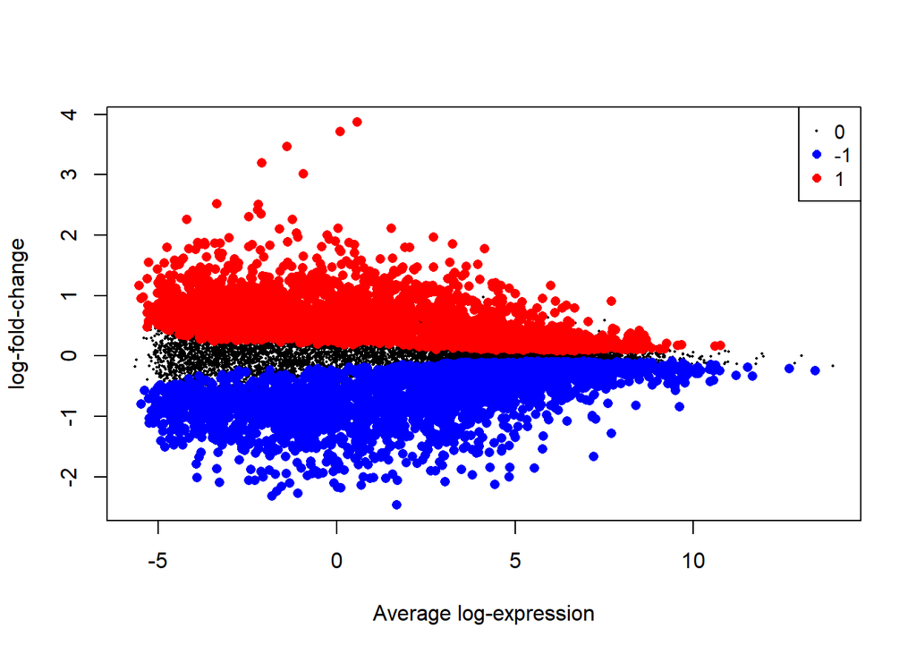

```r
#Genome - Wide plots
plotMD(fit.cont,coef="HvsL",status=summa.fit[,"HvsL"], values = c(-1, 1), hl.col=c("blue","red"))
```

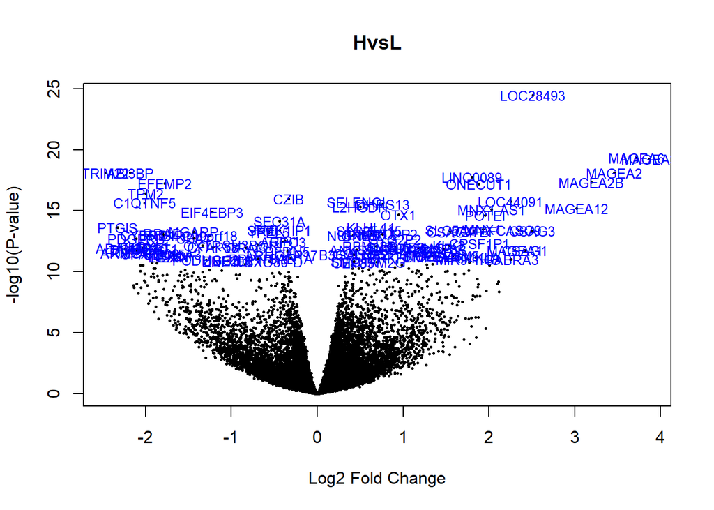

```r
volcanoplot(fit.cont,coef="HvsL",highlight=100,names=y$genes$SYMBOL, main="HvsL")
```

```r
glXYPlot(x=fit.cont$coefficients[,1], y=fit.cont$lods[,1],
         xlab="logFC", ylab="B", main="HvsL",
         counts=v$E, groups=Mutation_count, status=summa.fit[,1],
         anno=fit.cont$genes, side.main="ENSEMBL", folder="mut_counts_volcano", html = 'mut_counts_volcano')


#Testing relative to a threshold - TREAT
fit.treat <- treat(fit.cont,lfc=log2(1.2))

topTreat(fit.treat, coef="HvsL")
```

```
##                         ENSEMBL ENTREZID    SYMBOL
## ENSG00000224271 ENSG00000224271   284930 LOC284930
## ENSG00000197172 ENSG00000197172     4105    MAGEA6
## ENSG00000221867 ENSG00000221867     4102    MAGEA3
## ENSG00000268606 ENSG00000268606     4101    MAGEA2
## ENSG00000183305 ENSG00000183305   266740   MAGEA2B
## ENSG00000132274 ENSG00000132274    10346    TRIM22
## ENSG00000154175 ENSG00000154175    25890    ABI3BP
## ENSG00000205634 ENSG00000205634   400932 LINC00898
## ENSG00000169856 ENSG00000169856     3175   ONECUT1
## ENSG00000213401 ENSG00000213401     4111   MAGEA12
##                                                   GENENAME     logFC
## ENSG00000224271                  uncharacterized LOC284930  2.513089
## ENSG00000197172                      MAGE family member A6  3.717851
## ENSG00000221867                      MAGE family member A3  3.867042
## ENSG00000268606                      MAGE family member A2  3.461953
## ENSG00000183305                     MAGE family member A2B  3.192385
## ENSG00000132274             tripartite motif containing 22 -2.469650
## ENSG00000154175        ABI family member 3 binding protein -2.176098
## ENSG00000205634 long intergenic non-protein coding RNA 898  1.801097
## ENSG00000169856                         one cut homeobox 1  1.880362
## ENSG00000213401                     MAGE family member A12  3.017347
##                     AveExpr         t      P.Value    adj.P.Val
## ENSG00000224271 -3.35920463  9.531332 5.466318e-21 1.000664e-16
## ENSG00000197172  0.08835840  8.706897 6.191297e-18 3.807303e-14
## ENSG00000221867  0.56752939  8.705954 6.239435e-18 3.807303e-14
## ENSG00000268606 -1.39304852  8.350453 1.098090e-16 5.025408e-13
## ENSG00000183305 -2.09832915  8.095513 8.067639e-16 2.885526e-12
## ENSG00000132274  1.68023744 -8.074898 9.457639e-16 2.885526e-12
## ENSG00000154175  0.02837394 -7.946279 2.530045e-15 6.616429e-12
## ENSG00000205634 -4.75604969  7.638539 2.521976e-14 5.770911e-11
## ENSG00000169856 -3.89054517  7.558086 4.541684e-14 9.237785e-11
## ENSG00000213401 -0.93244959  7.495670 7.141986e-14 1.230759e-10
```

```r
res.treat <- decideTests(fit.treat)

summary(res.treat)
```

```
##         MvsL  HvsM  HvsL
## Down       0    18   698
## NotSig 18304 18276 17021
## Up         2    12   587
```

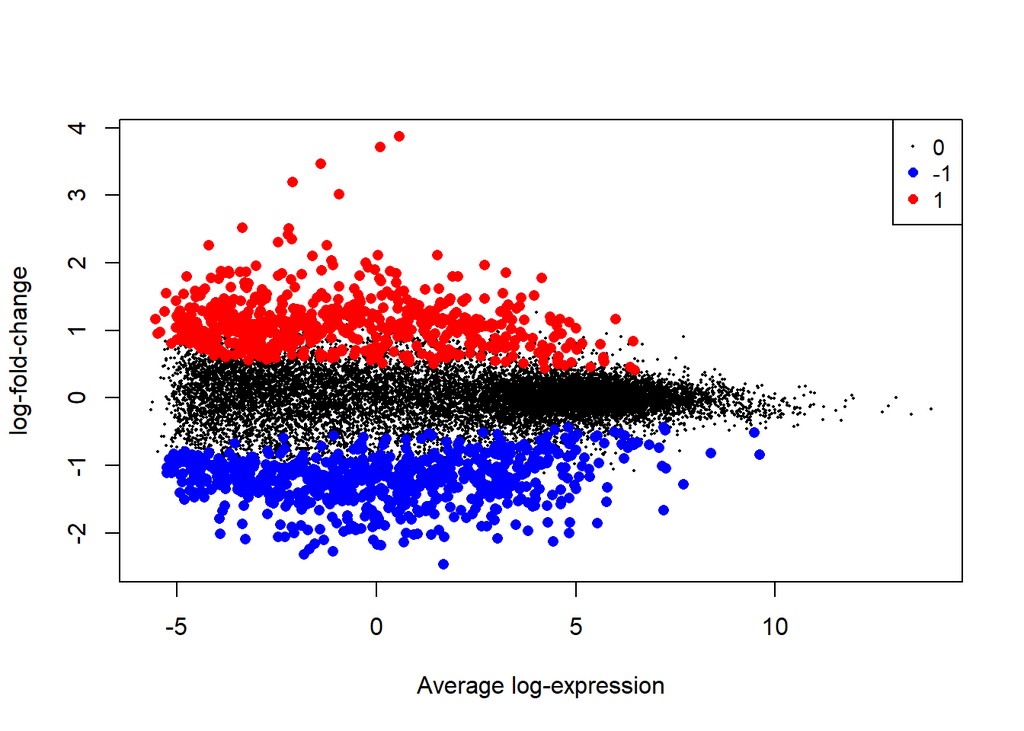

```r
#Treat plots
plotMD(fit.treat,coef="HvsL",status=res.treat[,"HvsL"], values = c(-1, 1), hl.col=c("blue","red"))
```

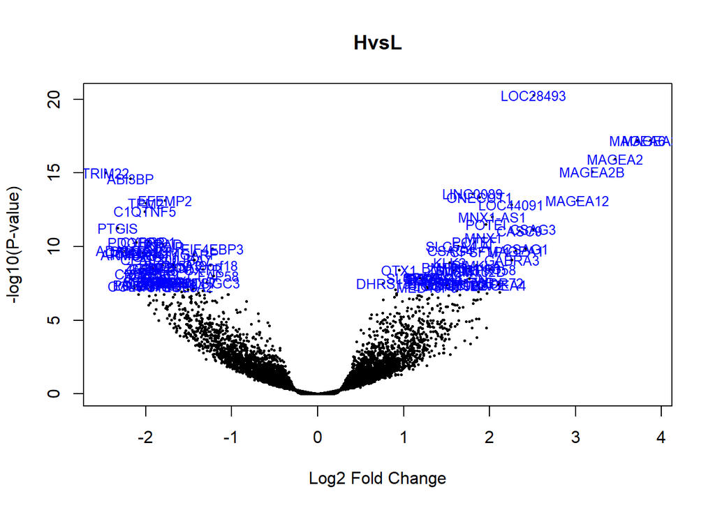

```r
volcanoplot(fit.treat,coef="HvsL",highlight=100,names=y$genes$SYMBOL, main="HvsL")
```

```r
glMDPlot(fit.treat, coef="HvsL", counts=v$E, groups=Mutation_count,
         status=res.treat, side.main="ENSEMBL", main="HvsL",
         folder="mut_counts_md", html = 'mut_counts_md')


#GO enrichment using goana on Treat results
go <- goana(fit.treat, coef="HvsL", geneid = fit.treat$genes$ENTREZID, species = "Hs")
topGO(go, n=10)
```

```
##                                                   Term Ont    N Up Down
## GO:0030198           extracellular matrix organization  BP  359  6   78
## GO:0043062        extracellular structure organization  BP  360  7   78
## GO:0031012                        extracellular matrix  CC  463 11   87
## GO:0062023    collagen-containing extracellular matrix  CC  349  7   72
## GO:0005576                        extracellular region  CC 3326 92  254
## GO:0005201 extracellular matrix structural constituent  MF  147  3   41
## GO:0005615                         extracellular space  CC 2629 75  195
## GO:0001944                     vasculature development  BP  653 15   81
## GO:0001568                    blood vessel development  BP  625 15   79
## GO:0007155                               cell adhesion  BP 1278 33  120
##                 P.Up       P.Down
## GO:0030198 0.9755389 4.834727e-37
## GO:0043062 0.9462310 5.961198e-37
## GO:0031012 0.8822087 4.043595e-36
## GO:0062023 0.9345182 1.133277e-32
## GO:0005576 0.9542000 3.428320e-31
## GO:0005201 0.8552647 2.449868e-24
## GO:0005615 0.8837494 2.384571e-21
## GO:0001944 0.9343305 3.746903e-21
## GO:0001568 0.9055702 3.747353e-21
## GO:0007155 0.9237398 1.419002e-20
```

Para esta análise foram definidos como contrastes **MvsL(Medium-Low)**, **HvsM(High-Medium)** e **HvsL(High-Low)**. Da filtragem efetuada, permaneceram na análise $18306$ linhagens das $30639$ iniciais. A análise do gráfico de barras permite inferir que existem linhagens celulares com *library sizes* bastante superiores a média. O *output* gráfico do *limma voom* demonstra que ocorre uma dispersão dos pontos principalmente para valores de $log2 < 10$.  
Da análise de expressão diferencial resulta que, numa fase inicial e para o contraste **MvsL** existem $553$ **genes subexpressos** e $690$ **sobrexpressos**, para o contraste **HvsM** existem $841$ **genes subexpressos** e $726$ **sobrexpressos** e para o contraste **HvsL** existem $3269$ **genes subexpressos** e $3466$ **sobrexpressos.** Isto pode ser analisado graficamente com recurso ao *MD plot* e ao *volcano plot* para o constraste **HvsL** . Após a análise *TREAT* (*Testing relative to a threshold*) verificou-se que restaram para o contraste **MvsL** $0$ **genes subexpressos** e $2$ **sobrexpressos**, para o contraste **HvsM** restaram $18$ **genes subexpressos** e $12$ **sobrexpressos** e para o contraste **HvsL** restaram $698$ **genes subexpressos** e $587$ **sobrexpressos**, o que também pode ser analisado graficamente com os gráficos já referidos para o contrate **HvsL**. [^2]  
Por último, a análise sobre as ontologias genéticas para o contraste **HvsL** permitiu inferir que se encontram **maioriatariamente subexpressos** genes associados a processos biológicos relacionados com a matriz extracelular, formação de vasos sanguíneos e vasculatura e adesão celular para o contraste referido. Isto **não** era o expectável, já que com a acumulação de mutações espera-se que os tumores evoluam no sentido de proliferarem, sendo para tal necessário a ação de genes relacionados com a angiogénese o que não está de acordo com estes resultados.

Voltar à análise

### Combinação

```r
#Carregar no EdgeR
y <- DGEList(counts = exp_matrix)

#Carregar anotação dos genes
y$genes <- ann

#Design for mutation types
Cancer_type <- meta_intersect$type
Mutation_count <- meta_intersect$mut_counts
Group <- factor(paste(Cancer_type,Mutation_count,sep="."))

design = model.matrix(~0+Group, data = y$samples)
colnames(design) <- levels(Group)
design
```

[output not shown]

[output cut: 1992 more lines]

```
## ACH-002062           0              0
## ACH-002065           0              0
## ACH-002066           0              1
## ACH-002067           0              1
## ACH-002069           0              1
## ACH-002446           0              0
## ACH-002508           0              0
## ACH-002509           0              0
## ACH-002510           0              0
## ACH-002511           1              0
## attr(,"assign")
## [1] 1 1 1 1 1 1
## attr(,"contrasts")
## attr(,"contrasts")$Group
## [1] "contr.treatment"
```

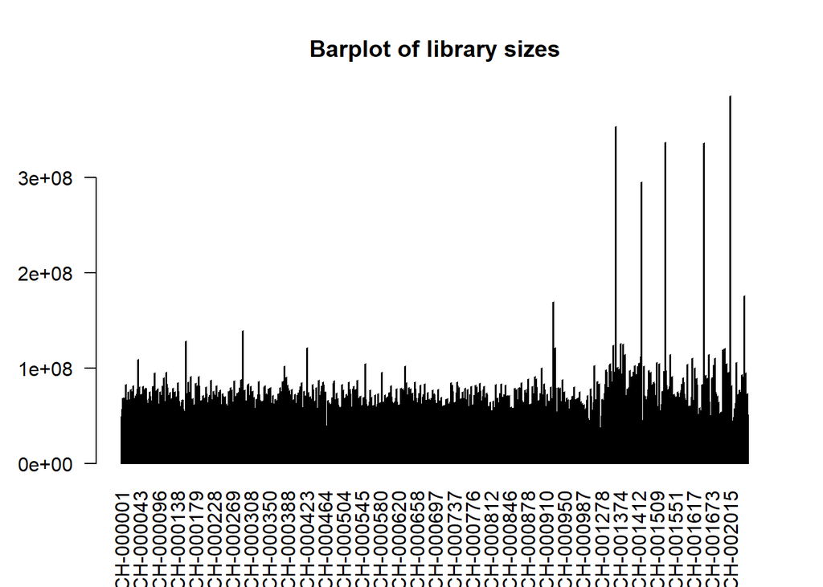

```r
#Make contrasts
contrast <- makeContrasts(MHvPH = Metastasis.High-Primary.High,
                          MLvsPL = Metastasis.Low-Primary.Low,
                          MHvsML = Metastasis.High-Metastasis.Low,
                          PHvsPL = Primary.High-Primary.Low,
                          MHvsPL = Metastasis.High-Primary.Low,
                          PHvML = Primary.High-Metastasis.Low,
                          levels=design)

keep <- filterByExpr(y, design)
y <- y[keep, , keep.lib.sizes=FALSE]

barplot(y$samples$lib.size,names=colnames(y),las=2)
# Add a title to the plot
title("Barplot of library sizes")
```

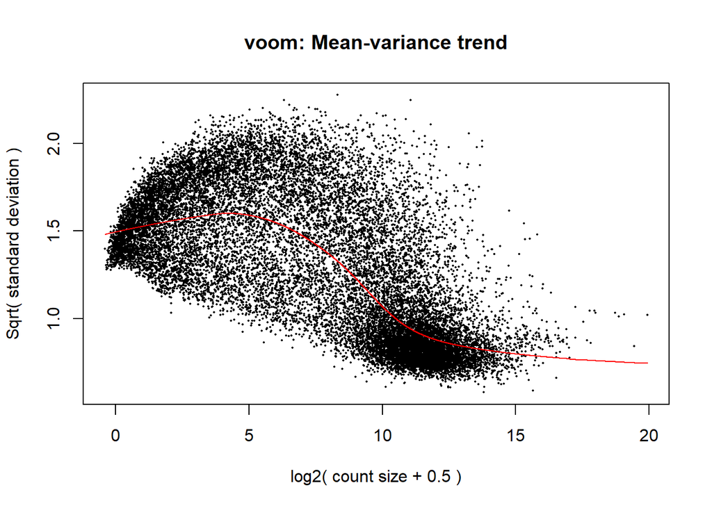

```r
# Calculate normalization factors for library sizes with TMM
y <- calcNormFactors(y)


#Start limma voom pipeline
par(mfrow=c(1,1))

v <- voom(y,design,plot = TRUE)
```

```r
#Limma - Trend
fit <- lmFit(v, design)

fit.cont <- contrasts.fit(fit, contrast)

fit.cont <- eBayes(fit.cont, trend = F, robust = F)

summa.fit <- decideTests(fit.cont)

summary(summa.fit)
```

```
##        MHvPH MLvsPL MHvsML PHvsPL MHvsPL PHvML
## Down     374    272   1038   2708   2909  1439
## NotSig 19091  19704  18069  14626  13446 17809
## Up       842    331   1200   2973   3952  1059
```

```r
topTable(fit.cont, coef="MHvsPL")
```

```
##                         ENSEMBL  ENTREZID    SYMBOL
## ENSG00000246430 ENSG00000246430 100507632 LINC00968
## ENSG00000183305 ENSG00000183305    266740   MAGEA2B
## ENSG00000268606 ENSG00000268606      4101    MAGEA2
## ENSG00000277363 ENSG00000277363     80725    SRCIN1
## ENSG00000132274 ENSG00000132274     10346    TRIM22
## ENSG00000197172 ENSG00000197172      4105    MAGEA6
## ENSG00000169857 ENSG00000169857     57099      AVEN
## ENSG00000224271 ENSG00000224271    284930 LOC284930
## ENSG00000213401 ENSG00000213401      4111   MAGEA12
## ENSG00000166710 ENSG00000166710       567       B2M
##                                                   GENENAME      logFC
## ENSG00000246430 long intergenic non-protein coding RNA 968 -2.4253069
## ENSG00000183305                     MAGE family member A2B  4.2937497
## ENSG00000268606                      MAGE family member A2  4.4600243
## ENSG00000277363           SRC kinase signaling inhibitor 1  2.3040632
## ENSG00000132274             tripartite motif containing 22 -3.4087908
## ENSG00000197172                      MAGE family member A6  4.4251704
## ENSG00000169857 apoptosis and caspase activation inhibitor -0.7673738
## ENSG00000224271                  uncharacterized LOC284930  2.6702617
## ENSG00000213401                     MAGE family member A12  3.8777537
## ENSG00000166710                       beta-2-microglobulin -1.3785826
##                     AveExpr          t      P.Value    adj.P.Val        B
## ENSG00000246430 -5.84864384 -10.086864 7.192833e-23 1.460649e-18 40.57412
## ENSG00000183305 -2.10067145   9.282142 9.723754e-20 9.873013e-16 33.64018
## ENSG00000268606 -1.39539081   9.153547 2.940517e-19 1.990436e-15 32.62649
## ENSG00000277363  1.57183082   8.838545 4.189565e-18 2.126938e-14 30.25358
## ENSG00000132274  1.67789515  -8.767955 7.518013e-18 3.053366e-14 29.76755
## ENSG00000197172  0.08601611   8.706038 1.251518e-17 4.235763e-14 29.10858
## ENSG00000169857  3.56402457  -8.503036 6.514444e-17 1.889840e-13 27.69736
## ENSG00000224271 -3.36154693   8.427157 1.196792e-16 3.037908e-13 26.81840
## ENSG00000213401 -0.93479188   8.217032 6.295630e-16 1.278454e-12 25.30120
## ENSG00000166710  9.60566687  -8.244545 5.075858e-16 1.145283e-12 25.24130
```

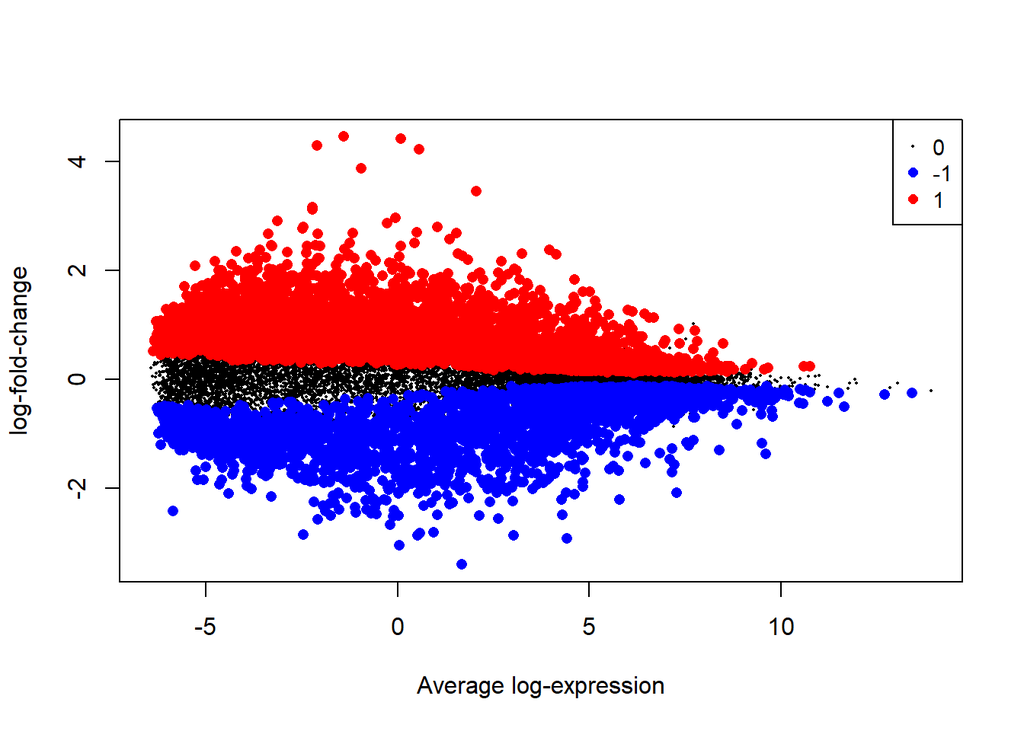

```r
#Genome - Wide plots
plotMD(fit.cont,coef="MHvsPL",status=summa.fit[,"MHvsPL"], values = c(-1, 1), hl.col=c("blue","red"))
```

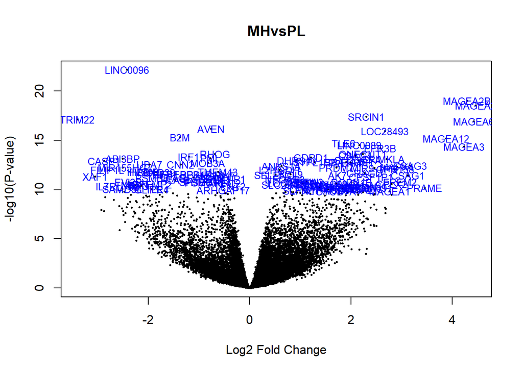

```r
volcanoplot(fit.cont,coef="MHvsPL",highlight=100,names=y$genes$SYMBOL, main="MHvsPL")
```

```r
glXYPlot(x=fit.cont$coefficients[,'MHvsPL'], y=fit.cont$lods[,'MHvsPL'],
         xlab="logFC", ylab="B", main="MHvsPL",
         counts=v$E, groups=Group, status=summa.fit[,'MHvsPL'],
         anno=fit.cont$genes, side.main="ENSEMBL", folder="combined_volcano", html = "combined_volcano")


#Testing relative to a threshold - TREAT
fit.treat <- treat(fit.cont,lfc=log2(1.2))

topTreat(fit.treat, coef="MHvsPL")
```

```
##                         ENSEMBL  ENTREZID    SYMBOL
## ENSG00000246430 ENSG00000246430 100507632 LINC00968
## ENSG00000183305 ENSG00000183305    266740   MAGEA2B
## ENSG00000268606 ENSG00000268606      4101    MAGEA2
## ENSG00000197172 ENSG00000197172      4105    MAGEA6
## ENSG00000132274 ENSG00000132274     10346    TRIM22
## ENSG00000277363 ENSG00000277363     80725    SRCIN1
## ENSG00000213401 ENSG00000213401      4111   MAGEA12
## ENSG00000224271 ENSG00000224271    284930 LOC284930
## ENSG00000221867 ENSG00000221867      4102    MAGEA3
## ENSG00000084710 ENSG00000084710     22979     EFR3B
##                                                   GENENAME     logFC
## ENSG00000246430 long intergenic non-protein coding RNA 968 -2.425307
## ENSG00000183305                     MAGE family member A2B  4.293750
## ENSG00000268606                      MAGE family member A2  4.460024
## ENSG00000197172                      MAGE family member A6  4.425170
## ENSG00000132274             tripartite motif containing 22 -3.408791
## ENSG00000277363           SRC kinase signaling inhibitor 1  2.304063
## ENSG00000213401                     MAGE family member A12  3.877754
## ENSG00000224271                  uncharacterized LOC284930  2.670262
## ENSG00000221867                      MAGE family member A3  4.233254
## ENSG00000084710                             EFR3 homolog B  2.581373
##                     AveExpr         t      P.Value    adj.P.Val
## ENSG00000246430 -5.84864384 -8.992903 5.753933e-19 1.168451e-14
## ENSG00000183305 -2.10067145  8.713520 5.885107e-18 5.975443e-14
## ENSG00000268606 -1.39539081  8.613707 1.330653e-17 9.007191e-14
## ENSG00000197172  0.08601611  8.188547 3.932369e-16 1.996365e-12
## ENSG00000132274  1.67789515 -8.091388 8.351515e-16 3.391884e-12
## ENSG00000277363  1.57183082  7.829527 6.123734e-15 2.072578e-11
## ENSG00000213401 -0.93479188  7.659657 2.164385e-14 6.278880e-11
## ENSG00000224271 -3.36154693  7.597039 3.425721e-14 8.695764e-11
## ENSG00000221867  0.56518710  7.474837 8.322015e-14 1.877724e-10
## ENSG00000084710  1.35699832  7.105933 1.122386e-12 2.279230e-09
```

```r
res.treat <- decideTests(fit.treat)

summary(res.treat)
```

```
##        MHvPH MLvsPL MHvsML PHvsPL MHvsPL PHvML
## Down       9     13     87    759    784   210
## NotSig 20230  20273  20098  18940  18348 20030
## Up        68     21    122    608   1175    67
```

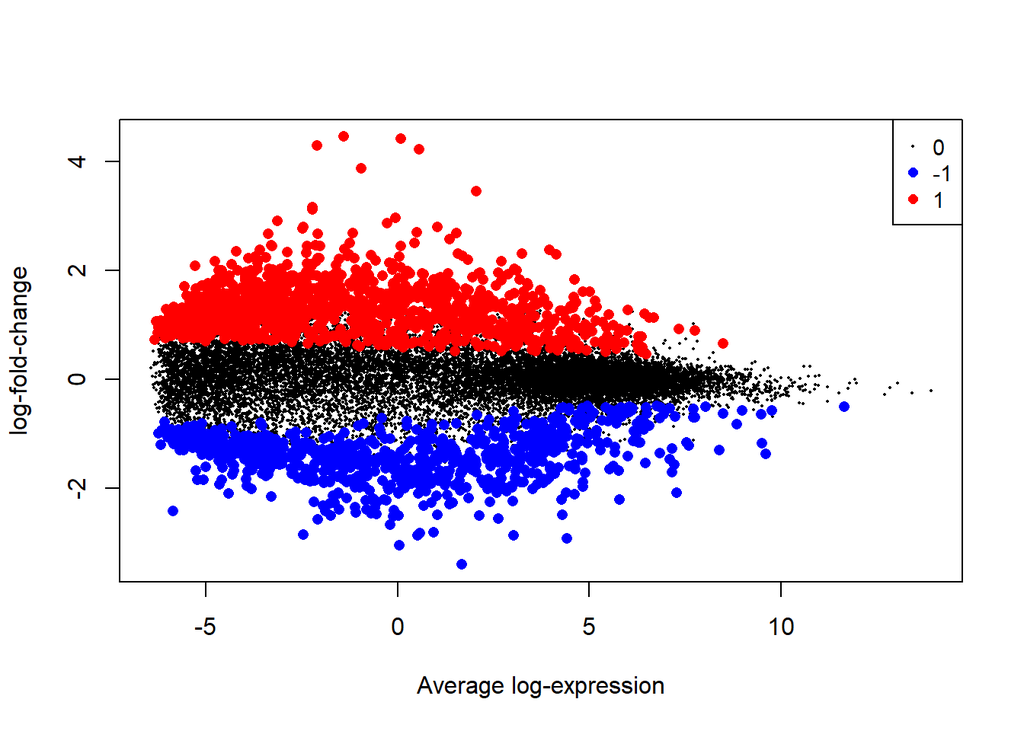

```r
plotMD(fit.treat,coef="MHvsPL",status=res.treat[,"MHvsPL"], values = c(-1, 1), hl.col=c("blue","red"))
```

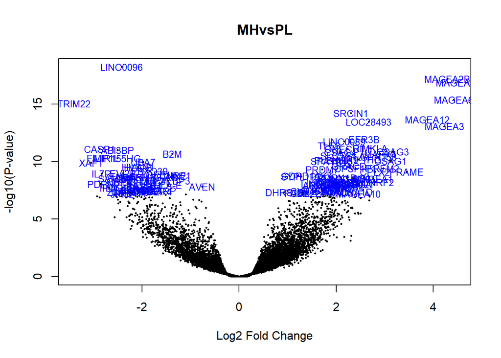

```r
volcanoplot(fit.treat,coef="MHvsPL",highlight=100,names=y$genes$SYMBOL, main="MHvsPL")
```

```r
glMDPlot(fit.treat, coef="MHvsPL", counts=v$E, groups=Group,
         status=res.treat, side.main="ENSEMBL", main="MHvsPL",
         folder="combined_md", html = "combined_md")


#GO enrichment using goana on Treat results
go <- goana(fit.treat, coef="MHvsPL", geneid = fit.treat$genes$ENTREZID, species = "Hs")
topGO(go, n=10)
```

```
##                                              Term Ont    N  Up Down      P.Up
## GO:0006955                        immune response  BP 1786  38  225 1.0000000
## GO:0002376                  immune system process  BP 2702  76  278 1.0000000
## GO:0006952                       defense response  BP 1440  33  190 1.0000000
## GO:0071345 cellular response to cytokine stimulus  BP 1016  24  155 1.0000000
## GO:0034097                   response to cytokine  BP 1099  26  159 1.0000000
## GO:0019221    cytokine-mediated signaling pathway  BP  709  12  126 1.0000000
## GO:0051707             response to other organism  BP 1256  26  167 1.0000000
## GO:0043207   response to external biotic stimulus  BP 1258  26  167 1.0000000
## GO:0009607            response to biotic stimulus  BP 1290  27  168 1.0000000
## GO:0005576                   extracellular region  CC 3691 183  308 0.9940966
##                  P.Down
## GO:0006955 4.300761e-61
## GO:0002376 3.047107e-58
## GO:0006952 8.991196e-54
## GO:0071345 1.837198e-51
## GO:0034097 1.025408e-49
## GO:0019221 7.307083e-49
## GO:0051707 3.097281e-47
## GO:0043207 3.857197e-47
## GO:0009607 2.713024e-46
## GO:0005576 3.060751e-45
```

```r
go_2 <- goana(fit.treat, coef="PHvsPL", geneid = fit.treat$genes$ENTREZID, species = "Hs")
topGO(go_2, n=10)
```

```
##                                                Term Ont    N Up Down      P.Up
## GO:0031012                     extracellular matrix  CC  516 10   99 0.9496293
## GO:0030198        extracellular matrix organization  BP  382  8   82 0.8909988
## GO:0043062     extracellular structure organization  BP  383  9   82 0.8166680
## GO:0005576                     extracellular region  CC 3691 97  287 0.9396060
## GO:0062023 collagen-containing extracellular matrix  CC  390  9   81 0.8322725
## GO:0016477                           cell migration  BP 1412 42  154 0.5510265
## GO:0030334             regulation of cell migration  BP  841 22  115 0.7782104
## GO:0040011                               locomotion  BP 1740 56  171 0.3129793
## GO:2000145              regulation of cell motility  BP  898 25  116 0.6824037
## GO:0040012                 regulation of locomotion  BP  933 26  117 0.6830102
##                  P.Down
## GO:0031012 1.656516e-42
## GO:0030198 5.331769e-39
## GO:0043062 6.556160e-39
## GO:0005576 1.713779e-38
## GO:0062023 2.055263e-37
## GO:0016477 1.296938e-34
## GO:0030334 1.593507e-34
## GO:0040011 6.229113e-33
## GO:2000145 1.782350e-32
## GO:0040012 1.516428e-31
```

Para esta análise foram definidos como contrastes **MHvPH (Metastasis.High-Primary.High)**, **MLvsPL (Metastasis.Low-Primary.Low)**, **MHvsML(Metastasis.High-Metastasis.Low)**, **PHvsPL(Primary.High-Primary.Low)**, **MHvsPL(Metastasis.High-Primary.Low)** e **PHvML(Primary.High-Metastasis.Low)**. Da filtragem efetuada, permaneceram na análise $20307$ linhagens das $30639$ iniciais. A análise do gráfico de barras permite inferir que existem linhagens celulares com *library sizes* bastante superiores à média. O *output* gráfico do *limma voom* demonstra que ocorre uma dispersão dos pontos principalmente para valores de $log2 < 10$.  
Da análise de expressão diferencial resulta que, numa fase inicial e para o contraste **MHvPH** existem $374$ **genes subexpressos** e $842$ **sobrexpressos**, para o contraste **MLvsPL** existem $272$ **genes subexpressos** e $331$ **sobrexpressos**, para o contraste **MHvsML** existem $1038$ **genes subexpressos** e $1200$ **sobrexpressos**, para o contraste **PHvsPL** existem $2708$ **genes subexpressos** e $2973$ **sobrexpressos**, para o contraste **MHvsPL** existem $2909$ **genes subexpressos** e $3952$ **sobrexpressos** e para o contraste **PHvsML** existem $1439$ **genes subexpressos** e $1059$ **sobrexpressos.** Isto pode ser analisado graficamente ao recurso ao *MD plot* e ao *volcano plot* para o constraste **MHvsPL**, que foi selecionado para os gráficos por ser aquele com **mais genes diferencialmente expressos**.  
Após a análise *TREAT* (*Testing relative to a threshold*) verificou-se que restaram para o contraste **MHvPH** $9$ **genes subexpressos** e $68$ **sobrexpressos**, para o contraste **MLvsPL** restaram $13$ **genes subexpressos** e $21$ **sobrexpressos**, para o contraste **MHvsML** restaram $87$ **genes subexpressos** e $122$ **sobrexpressos**, para o contraste **PHvsPL** restaram $759$ **genes subexpressos** e $608$ **sobrexpressos**, para o contraste **MHvsPL** restaram $784$ **genes subexpressos** e $1175$ **sobrexpressos** e para o contraste **PHvML** restaram $210$ **genes subexpressos** e $67$ **sobrexpressos.** Pode ser realizada uma análise gráfica com os gráficos já referidos para o contrate **MHvsPL**, que é aquele com **mais genes diferencialmente expressos**. [^3]  
Por último, a análise sobre as ontologias genéticas para o contrastes **MHvsPL** e **PHvsPL** permitiu inferir, para o primeiro, que se encontram **maioriatariamente subexpressos** genes associados a processos biológicos relacionados com a resposta imune, resposta a estímulos externos e resposta a citocinas. Estes são resultados ligeiramente diferentes aqueles que surgiram no contraste **MvsP**, com um maior ênfase para a resposta imune e com adição a subexpressão da resposta as citocinas. Isto irá permitir um aumento da proliferação celular, favorecendo o processo de carcinogénese.  
Já quanto ao segundo constraste observamos o mesmo padrão que no contraste **HvsL** anteriormente explorado, com uma **subexpressão** de genes associados à matriz extracelular, migração celular e locomoção celular. Isto leva a crer que com o acumular de mutações em tumores primários ocorre uma supressão destas vias o que não é expectável dado que esta acumulação de mutações esperar-se-ia direcionar o tumor no sentido da metastização. Contudo, também se verifica que a **subexpressão** de genes associados à matriz extracelular pode favorecer a neoplasia, o que pode explicar estes resultados.

Voltar à análise

Voltar ao início

[^1]: Uma versão interativa destes gráficos, gerada com o package *Glimma*, encontra-se disponível em HTML em anexo.
[^2]: Uma versão interativa destes gráficos, gerada com o package *Glimma*, encontra-se disponível em HTML em anexo.
[^3]: Uma versão interativa destes gráficos, gerada com o package *Glimma*, encontra-se disponível em HTML em anexo.